# Group 6 HCDR Project Phase 3

## Team Information

[figure not shown]

## Phase Leader Plan

[figure not shown]

## Credit Assignment Plan

[figure not shown]

## Home Credit Default Risk (HCDR)

The course project is based on the Home Credit Default Risk (HCDR) Kaggle Competition. The goal of this project is to predict whether or not a client will repay a loan. In order to make sure that people who struggle to get loans due to insufficient or non-existent credit histories have a positive loan experience, Home Credit makes use of a variety of alternative data--including telco and transactional information--to predict their clients' repayment abilities.

## Dataset analysis

Here we make use of data that has been already downloaded from the kaggle project and save it into variables so that visualization and analysis of data becomes easy

Home Credit is a non-banking financial institution, founded in 1997 in the Czech Republic.

The company operates in 14 countries (including United States, Russia, Kazahstan, Belarus, China, India) and focuses on lending primarily to people with little or no credit history which will either not obtain loans or became victims of untrustworthly lenders.

Home Credit group has over 29 million customers, total assests of 21 billions Euro, over 160 millions loans, with the majority in Asia and and almost half of them in China (as of 19-05-2018).

While Home Credit is currently using various statistical and machine learning methods to make these predictions, they're challenging Kagglers to help them unlock the full potential of their data. Doing so will ensure that clients capable of repayment are not rejected and that loans are given with a principal, maturity, and repayment calendar that will empower their clients to be successful.

### Data files overview

There are 7 different sources of data:

- **application_train/application_test (307k rows, and 48k rows):** the main training and testing data with information about each loan application at Home Credit. Every loan has its own row and is identified by the feature SK_ID_CURR. The training application data comes with the TARGET indicating 0: the loan was repaid or 1: the loan was not repaid. The target variable defines if the client had payment difficulties meaning he/she had late payment more than X days on at least one of the first Y installments of the loan. Such case is marked as 1 while other all other cases as 0.
- **bureau (1.7 Million rows):** data concerning client's previous credits from other financial institutions. Each previous credit has its own row in bureau, but one loan in the application data can have multiple previous credits.
- **bureau_balance (27 Million rows):** monthly data about the previous credits in bureau. Each row is one month of a previous credit, and a single previous credit can have multiple rows, one for each month of the credit length.
- **previous_application (1.6 Million rows):** previous applications for loans at Home Credit of clients who have loans in the application data. Each current loan in the application data can have multiple previous loans. Each previous application has one row and is identified by the feature SK_ID_PREV.
- **POS_CASH_BALANCE (10 Million rows):** monthly data about previous point of sale or cash loans clients have had with Home Credit. Each row is one month of a previous point of sale or cash loan, and a single previous loan can have many rows.
- **credit_card_balance:** monthly data about previous credit cards clients have had with Home Credit. Each row is one month of a credit card balance, and a single credit card can have many rows.
- **installments_payment (13.6 Million rows):** payment history for previous loans at Home Credit. There is one row for every made payment and one row for every missed payment.

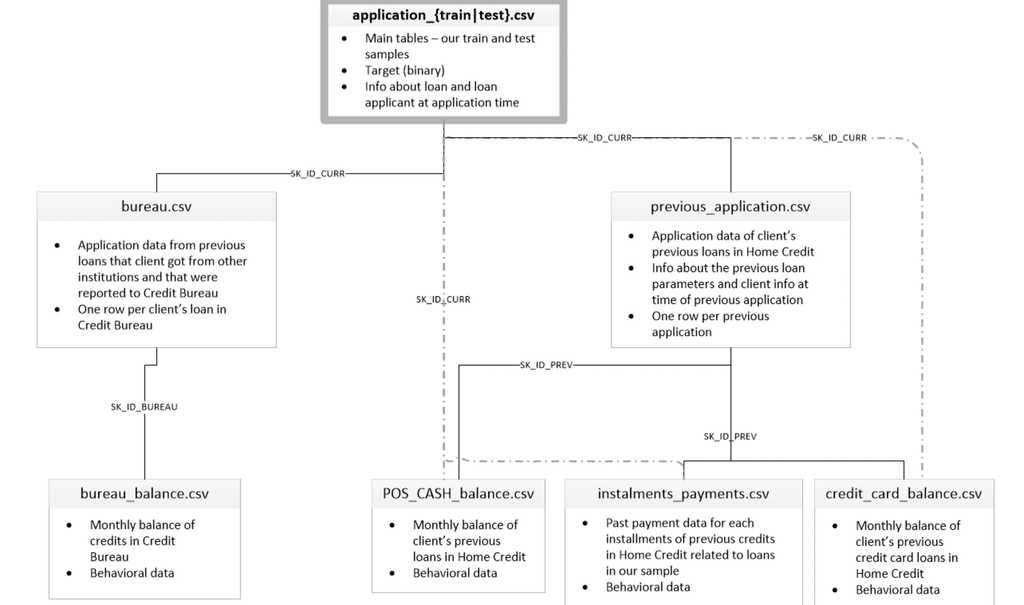

```python
import pandas as pd
import numpy as np

app_train = pd.read_csv('DATA_DIR/application_train.csv')
app_test = pd.read_csv('DATA_DIR/application_test.csv')
pre_app = pd.read_csv('DATA_DIR/previous_application.csv')
bureau = pd.read_csv('DATA_DIR/bureau.csv')
bureau_balance = pd.read_csv('DATA_DIR/bureau_balance.csv')
POS_CASH_balance = pd.read_csv('DATA_DIR/POS_CASH_balance.csv')
Instalments_pay = pd.read_csv('DATA_DIR/installments_payments.csv')
credit_card_balance = pd.read_csv('DATA_DIR/credit_card_balance.csv')
```

```python
print(bureau.shape)
bureau.head()
```

```
(1716428, 17)
```

|  | SK_ID_CURR | SK_ID_BUREAU | CREDIT_ACTIVE | CREDIT_CURRENCY | DAYS_CREDIT | CREDIT_DAY_OVERDUE | DAYS_CREDIT_ENDDATE | DAYS_ENDDATE_FACT | AMT_CREDIT_MAX_OVERDUE | CNT_CREDIT_PROLONG | AMT_CREDIT_SUM | AMT_CREDIT_SUM_DEBT | AMT_CREDIT_SUM_LIMIT | AMT_CREDIT_SUM_OVERDUE | CREDIT_TYPE | DAYS_CREDIT_UPDATE | AMT_ANNUITY |
| --- | --- | --- | --- | --- | --- | --- | --- | --- | --- | --- | --- | --- | --- | --- | --- | --- | --- |
| 0 | 215354 | 5714462 | Closed | currency 1 | -497 | 0 | -153.0 | -153.0 | NaN | 0 | 91323.0 | 0.0 | NaN | 0.0 | Consumer credit | -131 | NaN |
| 1 | 215354 | 5714463 | Active | currency 1 | -208 | 0 | 1075.0 | NaN | NaN | 0 | 225000.0 | 171342.0 | NaN | 0.0 | Credit card | -20 | NaN |
| 2 | 215354 | 5714464 | Active | currency 1 | -203 | 0 | 528.0 | NaN | NaN | 0 | 464323.5 | NaN | NaN | 0.0 | Consumer credit | -16 | NaN |
| 3 | 215354 | 5714465 | Active | currency 1 | -203 | 0 | NaN | NaN | NaN | 0 | 90000.0 | NaN | NaN | 0.0 | Credit card | -16 | NaN |
| 4 | 215354 | 5714466 | Active | currency 1 | -629 | 0 | 1197.0 | NaN | 77674.5 | 0 | 2700000.0 | NaN | NaN | 0.0 | Consumer credit | -21 | NaN |

```python
filtered_df = bureau[bureau['SK_ID_CURR'] == 100002]
filtered_df
```

|  | SK_ID_CURR | SK_ID_BUREAU | CREDIT_ACTIVE | CREDIT_CURRENCY | DAYS_CREDIT | CREDIT_DAY_OVERDUE | DAYS_CREDIT_ENDDATE | DAYS_ENDDATE_FACT | AMT_CREDIT_MAX_OVERDUE | CNT_CREDIT_PROLONG | AMT_CREDIT_SUM | AMT_CREDIT_SUM_DEBT | AMT_CREDIT_SUM_LIMIT | AMT_CREDIT_SUM_OVERDUE | CREDIT_TYPE | DAYS_CREDIT_UPDATE | AMT_ANNUITY |
| --- | --- | --- | --- | --- | --- | --- | --- | --- | --- | --- | --- | --- | --- | --- | --- | --- | --- |
| 675684 | 100002 | 6158904 | Closed | currency 1 | -1125 | 0 | -1038.0 | -1038.0 | NaN | 0 | 40761.000 | NaN | NaN | 0.0 | Credit card | -1038 | 0.0 |
| 675685 | 100002 | 6158905 | Closed | currency 1 | -476 | 0 | NaN | -48.0 | NaN | 0 | 0.000 | 0.0 | NaN | 0.0 | Credit card | -47 | NaN |
| 675686 | 100002 | 6158906 | Closed | currency 1 | -1437 | 0 | -1072.0 | -1185.0 | 0.000 | 0 | 135000.000 | 0.0 | 0.000 | 0.0 | Consumer credit | -1185 | 0.0 |
| 675687 | 100002 | 6158907 | Closed | currency 1 | -1121 | 0 | -911.0 | -911.0 | 3321.000 | 0 | 19071.000 | NaN | NaN | 0.0 | Consumer credit | -906 | 0.0 |
| 675688 | 100002 | 6158908 | Closed | currency 1 | -645 | 0 | 85.0 | -36.0 | 5043.645 | 0 | 120735.000 | 0.0 | 0.000 | 0.0 | Consumer credit | -34 | 0.0 |
| 675689 | 100002 | 6158909 | Active | currency 1 | -103 | 0 | NaN | NaN | 40.500 | 0 | 31988.565 | 0.0 | 31988.565 | 0.0 | Credit card | -24 | 0.0 |
| 1337779 | 100002 | 6158903 | Active | currency 1 | -1042 | 0 | 780.0 | NaN | NaN | 0 | 450000.000 | 245781.0 | 0.000 | 0.0 | Consumer credit | -7 | 0.0 |
| 1486113 | 100002 | 6113835 | Closed | currency 1 | -1043 | 0 | 62.0 | -967.0 | 0.000 | 0 | 67500.000 | NaN | NaN | 0.0 | Credit card | -758 | 0.0 |

```python
filtered_df = app_train[app_train['SK_ID_CURR'] == 215354]
filtered_df
```

|  | SK_ID_CURR | TARGET | NAME_CONTRACT_TYPE | CODE_GENDER | FLAG_OWN_CAR | FLAG_OWN_REALTY | CNT_CHILDREN | AMT_INCOME_TOTAL | AMT_CREDIT | AMT_ANNUITY | ... | FLAG_DOCUMENT_18 | FLAG_DOCUMENT_19 | FLAG_DOCUMENT_20 | FLAG_DOCUMENT_21 | AMT_REQ_CREDIT_BUREAU_HOUR | AMT_REQ_CREDIT_BUREAU_DAY | AMT_REQ_CREDIT_BUREAU_WEEK | AMT_REQ_CREDIT_BUREAU_MON | AMT_REQ_CREDIT_BUREAU_QRT | AMT_REQ_CREDIT_BUREAU_YEAR |
| --- | --- | --- | --- | --- | --- | --- | --- | --- | --- | --- | --- | --- | --- | --- | --- | --- | --- | --- | --- | --- | --- |
| 99355 | 215354 | 0 | Cash loans | F | Y | N | 0 | 270000.0 | 720000.0 | 21181.5 | ... | 0 | 0 | 0 | 0 | 0.0 | 0.0 | 0.0 | 0.0 | 0.0 | 3.0 |

1 rows × 122 columns

```python
print(app_train.shape)
app_train.head()
```

```
(307511, 122)
```

|  | SK_ID_CURR | TARGET | NAME_CONTRACT_TYPE | CODE_GENDER | FLAG_OWN_CAR | FLAG_OWN_REALTY | CNT_CHILDREN | AMT_INCOME_TOTAL | AMT_CREDIT | AMT_ANNUITY | ... | FLAG_DOCUMENT_18 | FLAG_DOCUMENT_19 | FLAG_DOCUMENT_20 | FLAG_DOCUMENT_21 | AMT_REQ_CREDIT_BUREAU_HOUR | AMT_REQ_CREDIT_BUREAU_DAY | AMT_REQ_CREDIT_BUREAU_WEEK | AMT_REQ_CREDIT_BUREAU_MON | AMT_REQ_CREDIT_BUREAU_QRT | AMT_REQ_CREDIT_BUREAU_YEAR |
| --- | --- | --- | --- | --- | --- | --- | --- | --- | --- | --- | --- | --- | --- | --- | --- | --- | --- | --- | --- | --- | --- |
| 0 | 100002 | 1 | Cash loans | M | N | Y | 0 | 202500.0 | 406597.5 | 24700.5 | ... | 0 | 0 | 0 | 0 | 0.0 | 0.0 | 0.0 | 0.0 | 0.0 | 1.0 |
| 1 | 100003 | 0 | Cash loans | F | N | N | 0 | 270000.0 | 1293502.5 | 35698.5 | ... | 0 | 0 | 0 | 0 | 0.0 | 0.0 | 0.0 | 0.0 | 0.0 | 0.0 |
| 2 | 100004 | 0 | Revolving loans | M | Y | Y | 0 | 67500.0 | 135000.0 | 6750.0 | ... | 0 | 0 | 0 | 0 | 0.0 | 0.0 | 0.0 | 0.0 | 0.0 | 0.0 |
| 3 | 100006 | 0 | Cash loans | F | N | Y | 0 | 135000.0 | 312682.5 | 29686.5 | ... | 0 | 0 | 0 | 0 | NaN | NaN | NaN | NaN | NaN | NaN |
| 4 | 100007 | 0 | Cash loans | M | N | Y | 0 | 121500.0 | 513000.0 | 21865.5 | ... | 0 | 0 | 0 | 0 | 0.0 | 0.0 | 0.0 | 0.0 | 0.0 | 0.0 |

5 rows × 122 columns

## Data Preprocessing and Visualization

```python
def drop_columns_by_missing_ratio(data, pct_missing):
    """
    Drops columns from the DataFrame if their missing value ratio is greater than pct_missing.

    Parameters:
    data (DataFrame): The pandas DataFrame to modify.
    pct_missing (float): The threshold for the missing value ratio. Columns with a missing value ratio higher than this will be dropped.

    Returns:
    DataFrame: The modified DataFrame with specified columns dropped.
    """
    # Calculate the missing ratio for each column
    missing_ratio = data.isnull().sum() / len(data) * 100

    # Find columns where the missing ratio is greater than pct_missing
    columns_to_drop = missing_ratio[missing_ratio > pct_missing].index

    # Drop these columns
    data_dropped = data.drop(columns=columns_to_drop)

    return data_dropped
```

```python
app_train_df=drop_columns_by_missing_ratio(app_train,35)
print(app_train_df.shape)
app_train_df.head()
```

```
(307511, 73)
```

|  | SK_ID_CURR | TARGET | NAME_CONTRACT_TYPE | CODE_GENDER | FLAG_OWN_CAR | FLAG_OWN_REALTY | CNT_CHILDREN | AMT_INCOME_TOTAL | AMT_CREDIT | AMT_ANNUITY | ... | FLAG_DOCUMENT_18 | FLAG_DOCUMENT_19 | FLAG_DOCUMENT_20 | FLAG_DOCUMENT_21 | AMT_REQ_CREDIT_BUREAU_HOUR | AMT_REQ_CREDIT_BUREAU_DAY | AMT_REQ_CREDIT_BUREAU_WEEK | AMT_REQ_CREDIT_BUREAU_MON | AMT_REQ_CREDIT_BUREAU_QRT | AMT_REQ_CREDIT_BUREAU_YEAR |
| --- | --- | --- | --- | --- | --- | --- | --- | --- | --- | --- | --- | --- | --- | --- | --- | --- | --- | --- | --- | --- | --- |
| 0 | 100002 | 1 | Cash loans | M | N | Y | 0 | 202500.0 | 406597.5 | 24700.5 | ... | 0 | 0 | 0 | 0 | 0.0 | 0.0 | 0.0 | 0.0 | 0.0 | 1.0 |
| 1 | 100003 | 0 | Cash loans | F | N | N | 0 | 270000.0 | 1293502.5 | 35698.5 | ... | 0 | 0 | 0 | 0 | 0.0 | 0.0 | 0.0 | 0.0 | 0.0 | 0.0 |
| 2 | 100004 | 0 | Revolving loans | M | Y | Y | 0 | 67500.0 | 135000.0 | 6750.0 | ... | 0 | 0 | 0 | 0 | 0.0 | 0.0 | 0.0 | 0.0 | 0.0 | 0.0 |
| 3 | 100006 | 0 | Cash loans | F | N | Y | 0 | 135000.0 | 312682.5 | 29686.5 | ... | 0 | 0 | 0 | 0 | NaN | NaN | NaN | NaN | NaN | NaN |
| 4 | 100007 | 0 | Cash loans | M | N | Y | 0 | 121500.0 | 513000.0 | 21865.5 | ... | 0 | 0 | 0 | 0 | 0.0 | 0.0 | 0.0 | 0.0 | 0.0 | 0.0 |

5 rows × 73 columns

```python
def list_columns_with_few_unique_values(df, max_unique_values=5):
    """
    Lists all columns in the DataFrame that have less than a specified number of unique values,
    along with those unique values.

    Parameters:
    df (DataFrame): The pandas DataFrame to analyze.
    max_unique_values (int): The maximum number of unique values a column should have to be included.

    Returns:
    dict: A dictionary where keys are column names and values are lists of unique values in those columns.
    """
    columns_with_few_unique_values = {}

    for column in df.columns:
        unique_values = df[column].unique()
        if len(unique_values) < max_unique_values:
            columns_with_few_unique_values[column] = unique_values

    return columns_with_few_unique_values
```

```python
list_columns_with_few_unique_values(app_train_df)
```

```
{'TARGET': array([1, 0]),
 'NAME_CONTRACT_TYPE': array(['Cash loans', 'Revolving loans'], dtype=object),
 'CODE_GENDER': array(['M', 'F', 'XNA'], dtype=object),
 'FLAG_OWN_CAR': array(['N', 'Y'], dtype=object),
 'FLAG_OWN_REALTY': array(['Y', 'N'], dtype=object),
 'FLAG_MOBIL': array([1, 0]),
 'FLAG_EMP_PHONE': array([1, 0]),
 'FLAG_WORK_PHONE': array([0, 1]),
 'FLAG_CONT_MOBILE': array([1, 0]),
 'FLAG_PHONE': array([1, 0]),
 'FLAG_EMAIL': array([0, 1]),
 'REGION_RATING_CLIENT': array([2, 1, 3]),
 'REGION_RATING_CLIENT_W_CITY': array([2, 1, 3]),
 'REG_REGION_NOT_LIVE_REGION': array([0, 1]),
 'REG_REGION_NOT_WORK_REGION': array([0, 1]),
 'LIVE_REGION_NOT_WORK_REGION': array([0, 1]),
 'REG_CITY_NOT_LIVE_CITY': array([0, 1]),
 'REG_CITY_NOT_WORK_CITY': array([0, 1]),
 'LIVE_CITY_NOT_WORK_CITY': array([0, 1]),
 'FLAG_DOCUMENT_2': array([0, 1]),
 'FLAG_DOCUMENT_3': array([1, 0]),
 'FLAG_DOCUMENT_4': array([0, 1]),
 'FLAG_DOCUMENT_5': array([0, 1]),
 'FLAG_DOCUMENT_6': array([0, 1]),
 'FLAG_DOCUMENT_7': array([0, 1]),
 'FLAG_DOCUMENT_8': array([0, 1]),
 'FLAG_DOCUMENT_9': array([0, 1]),
 'FLAG_DOCUMENT_10': array([0, 1]),
 'FLAG_DOCUMENT_11': array([0, 1]),
 'FLAG_DOCUMENT_12': array([0, 1]),
 'FLAG_DOCUMENT_13': array([0, 1]),
 'FLAG_DOCUMENT_14': array([0, 1]),
 'FLAG_DOCUMENT_15': array([0, 1]),
 'FLAG_DOCUMENT_16': array([0, 1]),
 'FLAG_DOCUMENT_17': array([0, 1]),
 'FLAG_DOCUMENT_18': array([0, 1]),
 'FLAG_DOCUMENT_19': array([0, 1]),
 'FLAG_DOCUMENT_20': array([0, 1]),
 'FLAG_DOCUMENT_21': array([0, 1])}
```

```python
def convert_to_categorical(df, max_unique_values=5):
    """
    Converts columns in the DataFrame to categorical if they are numerical and
    have fewer than a specified number of unique values.

    Parameters:
    df (DataFrame): The pandas DataFrame to modify.
    max_unique_values (int): The maximum number of unique values a column should have to be converted.

    Returns:
    DataFrame: The modified DataFrame with specified columns converted to categorical.
    """
    for column in df.select_dtypes(include=['number']).columns:
        if df[column].nunique() < max_unique_values:
            df[column] = df[column].astype(str).astype('category')

    return df
```

```python
convert_to_categorical(app_train_df)
```

|  | SK_ID_CURR | TARGET | NAME_CONTRACT_TYPE | CODE_GENDER | FLAG_OWN_CAR | FLAG_OWN_REALTY | CNT_CHILDREN | AMT_INCOME_TOTAL | AMT_CREDIT | AMT_ANNUITY | ... | FLAG_DOCUMENT_18 | FLAG_DOCUMENT_19 | FLAG_DOCUMENT_20 | FLAG_DOCUMENT_21 | AMT_REQ_CREDIT_BUREAU_HOUR | AMT_REQ_CREDIT_BUREAU_DAY | AMT_REQ_CREDIT_BUREAU_WEEK | AMT_REQ_CREDIT_BUREAU_MON | AMT_REQ_CREDIT_BUREAU_QRT | AMT_REQ_CREDIT_BUREAU_YEAR |
| --- | --- | --- | --- | --- | --- | --- | --- | --- | --- | --- | --- | --- | --- | --- | --- | --- | --- | --- | --- | --- | --- |
| 0 | 100002 | 1 | Cash loans | M | N | Y | 0 | 202500.0 | 406597.5 | 24700.5 | ... | 0 | 0 | 0 | 0 | 0.0 | 0.0 | 0.0 | 0.0 | 0.0 | 1.0 |
| 1 | 100003 | 0 | Cash loans | F | N | N | 0 | 270000.0 | 1293502.5 | 35698.5 | ... | 0 | 0 | 0 | 0 | 0.0 | 0.0 | 0.0 | 0.0 | 0.0 | 0.0 |
| 2 | 100004 | 0 | Revolving loans | M | Y | Y | 0 | 67500.0 | 135000.0 | 6750.0 | ... | 0 | 0 | 0 | 0 | 0.0 | 0.0 | 0.0 | 0.0 | 0.0 | 0.0 |
| 3 | 100006 | 0 | Cash loans | F | N | Y | 0 | 135000.0 | 312682.5 | 29686.5 | ... | 0 | 0 | 0 | 0 | NaN | NaN | NaN | NaN | NaN | NaN |
| 4 | 100007 | 0 | Cash loans | M | N | Y | 0 | 121500.0 | 513000.0 | 21865.5 | ... | 0 | 0 | 0 | 0 | 0.0 | 0.0 | 0.0 | 0.0 | 0.0 | 0.0 |
| ... | ... | ... | ... | ... | ... | ... | ... | ... | ... | ... | ... | ... | ... | ... | ... | ... | ... | ... | ... | ... | ... |
| 307506 | 456251 | 0 | Cash loans | M | N | N | 0 | 157500.0 | 254700.0 | 27558.0 | ... | 0 | 0 | 0 | 0 | NaN | NaN | NaN | NaN | NaN | NaN |
| 307507 | 456252 | 0 | Cash loans | F | N | Y | 0 | 72000.0 | 269550.0 | 12001.5 | ... | 0 | 0 | 0 | 0 | NaN | NaN | NaN | NaN | NaN | NaN |
| 307508 | 456253 | 0 | Cash loans | F | N | Y | 0 | 153000.0 | 677664.0 | 29979.0 | ... | 0 | 0 | 0 | 0 | 1.0 | 0.0 | 0.0 | 1.0 | 0.0 | 1.0 |
| 307509 | 456254 | 1 | Cash loans | F | N | Y | 0 | 171000.0 | 370107.0 | 20205.0 | ... | 0 | 0 | 0 | 0 | 0.0 | 0.0 | 0.0 | 0.0 | 0.0 | 0.0 |
| 307510 | 456255 | 0 | Cash loans | F | N | N | 0 | 157500.0 | 675000.0 | 49117.5 | ... | 0 | 0 | 0 | 0 | 0.0 | 0.0 | 0.0 | 2.0 | 0.0 | 1.0 |

307511 rows × 73 columns

```python
def list_and_count_column_types(df):
    """
    Lists and counts the numerical and categorical columns in a pandas DataFrame.

    Parameters:
    df (DataFrame): The pandas DataFrame to analyze.

    Returns:
    tuple: A tuple containing two lists (numerical columns, categorical columns) and two integers (count of numerical columns, count of categorical columns).
    """
    # Selecting numerical columns
    numerical_cols = df.select_dtypes(include=['number']).columns.tolist()
    num_numerical_cols = len(numerical_cols)

    # Selecting categorical columns
    # Assuming 'object' and 'category' dtypes as categorical
    categorical_cols = df.select_dtypes(include=['object', 'category']).columns.tolist()
    num_categorical_cols = len(categorical_cols)
    return numerical_cols, categorical_cols, num_numerical_cols, num_categorical_cols
```

```python
list_and_count_column_types(app_train_df)
```

```
(['SK_ID_CURR',
  'CNT_CHILDREN',
  'AMT_INCOME_TOTAL',
  'AMT_CREDIT',
  'AMT_ANNUITY',
  'AMT_GOODS_PRICE',
  'REGION_POPULATION_RELATIVE',
  'DAYS_BIRTH',
  'DAYS_EMPLOYED',
  'DAYS_REGISTRATION',
  'DAYS_ID_PUBLISH',
  'CNT_FAM_MEMBERS',
  'HOUR_APPR_PROCESS_START',
  'EXT_SOURCE_2',
  'EXT_SOURCE_3',
  'OBS_30_CNT_SOCIAL_CIRCLE',
  'DEF_30_CNT_SOCIAL_CIRCLE',
  'OBS_60_CNT_SOCIAL_CIRCLE',
  'DEF_60_CNT_SOCIAL_CIRCLE',
  'DAYS_LAST_PHONE_CHANGE',
  'AMT_REQ_CREDIT_BUREAU_HOUR',
  'AMT_REQ_CREDIT_BUREAU_DAY',
  'AMT_REQ_CREDIT_BUREAU_WEEK',
  'AMT_REQ_CREDIT_BUREAU_MON',
  'AMT_REQ_CREDIT_BUREAU_QRT',
  'AMT_REQ_CREDIT_BUREAU_YEAR'],
 ['TARGET',
  'NAME_CONTRACT_TYPE',
  'CODE_GENDER',
  'FLAG_OWN_CAR',
  'FLAG_OWN_REALTY',
  'NAME_TYPE_SUITE',
  'NAME_INCOME_TYPE',
  'NAME_EDUCATION_TYPE',
  'NAME_FAMILY_STATUS',
  'NAME_HOUSING_TYPE',
  'FLAG_MOBIL',
  'FLAG_EMP_PHONE',
  'FLAG_WORK_PHONE',
  'FLAG_CONT_MOBILE',
```

[output cut: 20 more lines]

```
  'FLAG_DOCUMENT_9',
  'FLAG_DOCUMENT_10',
  'FLAG_DOCUMENT_11',
  'FLAG_DOCUMENT_12',
  'FLAG_DOCUMENT_13',
  'FLAG_DOCUMENT_14',
  'FLAG_DOCUMENT_15',
  'FLAG_DOCUMENT_16',
  'FLAG_DOCUMENT_17',
  'FLAG_DOCUMENT_18',
  'FLAG_DOCUMENT_19',
  'FLAG_DOCUMENT_20',
  'FLAG_DOCUMENT_21'],
 26,
 47)
```

```python
app_train_df = app_train_df[app_train_df['CODE_GENDER'] != 'XNA']
app_train_df.sample(5)
```

|  | SK_ID_CURR | TARGET | NAME_CONTRACT_TYPE | CODE_GENDER | FLAG_OWN_CAR | FLAG_OWN_REALTY | CNT_CHILDREN | AMT_INCOME_TOTAL | AMT_CREDIT | AMT_ANNUITY | ... | FLAG_DOCUMENT_18 | FLAG_DOCUMENT_19 | FLAG_DOCUMENT_20 | FLAG_DOCUMENT_21 | AMT_REQ_CREDIT_BUREAU_HOUR | AMT_REQ_CREDIT_BUREAU_DAY | AMT_REQ_CREDIT_BUREAU_WEEK | AMT_REQ_CREDIT_BUREAU_MON | AMT_REQ_CREDIT_BUREAU_QRT | AMT_REQ_CREDIT_BUREAU_YEAR |
| --- | --- | --- | --- | --- | --- | --- | --- | --- | --- | --- | --- | --- | --- | --- | --- | --- | --- | --- | --- | --- | --- |
| 265126 | 407040 | 0 | Cash loans | F | Y | Y | 0 | 139500.0 | 526491.0 | 19039.5 | ... | 0 | 0 | 0 | 0 | 0.0 | 0.0 | 0.0 | 0.0 | 0.0 | 2.0 |
| 223821 | 359236 | 0 | Cash loans | F | N | N | 1 | 112500.0 | 675000.0 | 26154.0 | ... | 0 | 0 | 0 | 0 | 0.0 | 0.0 | 0.0 | 0.0 | 0.0 | 2.0 |
| 6128 | 107163 | 0 | Cash loans | F | Y | Y | 0 | 225000.0 | 1113399.0 | 47304.0 | ... | 0 | 0 | 0 | 0 | 0.0 | 0.0 | 1.0 | 0.0 | 0.0 | 3.0 |
| 25739 | 129924 | 0 | Cash loans | F | N | Y | 0 | 202500.0 | 358213.5 | 18324.0 | ... | 0 | 0 | 0 | 0 | 0.0 | 0.0 | 0.0 | 0.0 | 0.0 | 0.0 |
| 178063 | 306347 | 0 | Cash loans | F | N | Y | 0 | 139500.0 | 254700.0 | 24939.0 | ... | 0 | 0 | 0 | 0 | NaN | NaN | NaN | NaN | NaN | NaN |

5 rows × 73 columns

```python
app_train_df['DAYS_BIRTH'].sample(10)
```

```
228585   -16969
128081   -15835
23224    -15914
288776    -9531
256214   -22180
218823   -20046
96971    -14180
273977   -15237
60869    -11656
96721    -21601
Name: DAYS_BIRTH, dtype: int64
```

```
TARGET
0    282682
1     24825
Name: count, dtype: int64
```

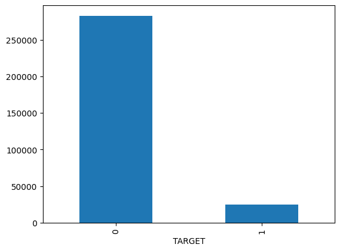

```python
# find number of good and bad loans
print(app_train_df.TARGET.value_counts())
app_train_df.TARGET.value_counts().plot(kind = 'bar')
```

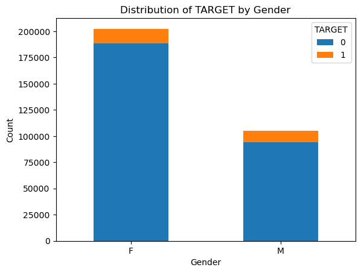

```python
# plot to see male or Female who is likely to have a bad loan
import pandas as pd
import seaborn as sns
import matplotlib.pyplot as plt

# Load your DataFrame
# app_train_df = ...

# Prepare the data for plotting
plot_data = pd.crosstab(app_train_df['CODE_GENDER'], app_train_df['TARGET'])

# Plotting
plot_data.plot(kind='bar', stacked=True)
plt.title('Distribution of TARGET by Gender')
plt.xlabel('Gender')
plt.ylabel('Count')
plt.xticks(rotation=0)
plt.legend(title='TARGET', labels=['0', '1'])
plt.show()
```

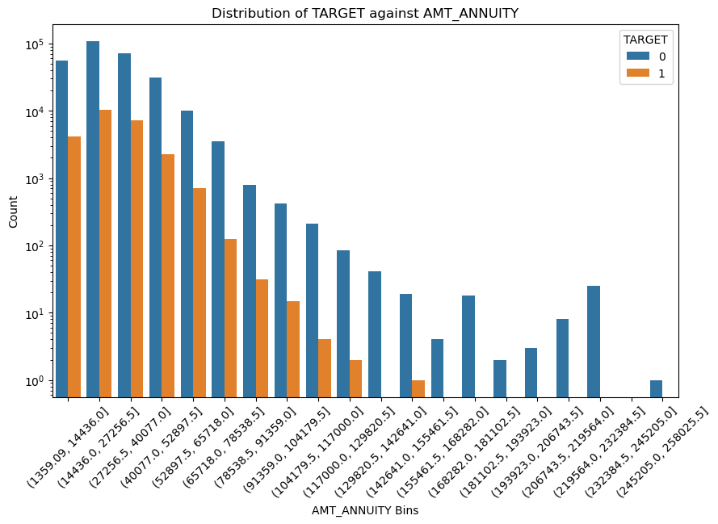

```python
import pandas as pd
import seaborn as sns
import matplotlib.pyplot as plt

# Load your DataFrame
# app_train_df = ...

# Bin the 'AMT_ANNUITY' column into categories
app_train_df['AMT_ANNUITY_BIN'] = pd.cut(app_train_df['AMT_ANNUITY'], bins=20)

# Creating a count plot
plt.figure(figsize=(10, 6))
sns.countplot(x='AMT_ANNUITY_BIN', hue='TARGET', data=app_train_df)
plt.xticks(rotation=45)
plt.yscale('log')  # Set the y-axis to a logarithmic scale
plt.title('Distribution of TARGET against AMT_ANNUITY')
plt.xlabel('AMT_ANNUITY Bins')
plt.ylabel('Count')
plt.show()
```

```python
from scipy.stats import pearsonr

def calculate_correlations(df, target_column):
    """
    Calculates correlations of each column in the DataFrame with a specified target column,
    excluding rows where either the column or the target has missing values.
    Returns the top 10 and bottom 10 correlations.

    Parameters:
    df (DataFrame): The pandas DataFrame to analyze.
    target_column (str): The name of the target column.

    Returns:
    dict: Two dictionaries containing the top 10 and bottom 10 correlations.
    """
    correlations = {}

    # Ensure the target column is numeric
    if df[target_column].dtype not in [np.float64, np.int64]:
        df[target_column] = pd.to_numeric(df[target_column], errors='coerce')

    for col in df.columns:
        if col != target_column and df[col].dtype in [np.float64, np.int64]:
            # Drop rows where either the column or the target column is missing
            temp_df = df[[col, target_column]].dropna()

            # Calculate correlation if both columns have more than 1 unique value
            if len(temp_df[col].unique()) > 1 and len(temp_df[target_column].unique()) > 1:
                corr, _ = pearsonr(temp_df[col], temp_df[target_column])
                correlations[col] = corr

    # Sort correlations by absolute value and get top 10 and bottom 10
    top_10 = dict(sorted(correlations.items(), key=lambda item: abs(item[1]), reverse=True)[:10])
    bottom_10 = dict(sorted(correlations.items(), key=lambda item: abs(item[1]))[:10])

    return top_10, bottom_10

# Usage example:
# top_10_correlations, bottom_10_correlations = calculate_correlations(df, 'TARGET')
calculate_correlations(app_train_df,'TARGET')
```

```
({'EXT_SOURCE_3': -0.1789262756761229,
  'EXT_SOURCE_2': -0.1604713343891351,
  'DAYS_BIRTH': 0.0782421600363702,
  'DAYS_LAST_PHONE_CHANGE': 0.055219303508842084,
  'DAYS_ID_PUBLISH': 0.051457257258225524,
  'DAYS_EMPLOYED': -0.04493360884917842,
  'DAYS_REGISTRATION': 0.04197612841208433,
  'AMT_GOODS_PRICE': -0.039646694496099706,
  'REGION_POPULATION_RELATIVE': -0.0372248666936824,
  'DEF_30_CNT_SOCIAL_CIRCLE': 0.03226131615737278},
 {'AMT_REQ_CREDIT_BUREAU_WEEK': 0.0007869822350146656,
  'AMT_REQ_CREDIT_BUREAU_HOUR': 0.00093009312467834,
  'AMT_REQ_CREDIT_BUREAU_QRT': -0.0020220179941566182,
  'SK_ID_CURR': -0.0021113928297126663,
  'AMT_REQ_CREDIT_BUREAU_DAY': 0.0027041282607051667,
  'AMT_INCOME_TOTAL': -0.003981577066657796,
  'OBS_60_CNT_SOCIAL_CIRCLE': 0.009027060438543195,
  'OBS_30_CNT_SOCIAL_CIRCLE': 0.009135511771162076,
  'CNT_FAM_MEMBERS': 0.009310394410131742,
  'AMT_REQ_CREDIT_BUREAU_MON': -0.012460349945656719})
```

```python
import pandas as pd
import scipy.stats as ss

def calculate_categorical_associations(df, target_column):
    """
    Calculates the association (using Chi-Square test of independence) of each categorical
    variable in the DataFrame with a specified target column, excluding rows where
    either the variable or the target has missing values. Returns variables with p-values less than 0.05.

    Parameters:
    df (DataFrame): The pandas DataFrame to analyze.
    target_column (str): The name of the target column.

    Returns:
    dict: A dictionary containing variables with p-values less than 0.05.
    """
    significant_associations = {}

    for col in df.select_dtypes(include=['object', 'category']).columns:
        if col != target_column:
            # Drop rows where either the column or the target column is missing
            temp_df = df[[col, target_column]].dropna()

            # Calculate Chi-Square test of independence
            chi2, p, _, _ = ss.chi2_contingency(pd.crosstab(temp_df[col], temp_df[target_column]))

            # Check for significance
            if p < 0.05:
                significant_associations[col] = p

    return significant_associations

# Usage example:
# significant_assoc = calculate_categorical_associations(df, 'TARGET')
calculate_categorical_associations(app_train_df,'TARGET')
```

```
{'NAME_CONTRACT_TYPE': 1.1274999190439244e-65,
 'CODE_GENDER': 4.394091339983112e-202,
 'FLAG_OWN_CAR': 9.410574445435379e-34,
 'FLAG_OWN_REALTY': 0.0006716541669272183,
 'NAME_TYPE_SUITE': 1.1360708640852924e-05,
 'NAME_INCOME_TYPE': 1.8519174689246325e-266,
 'NAME_EDUCATION_TYPE': 2.462768187281063e-219,
 'NAME_FAMILY_STATUS': 7.717800159426534e-107,
 'NAME_HOUSING_TYPE': 1.1058276330411495e-88,
 'FLAG_EMP_PHONE': 2.47393959459949e-143,
 'FLAG_WORK_PHONE': 2.4872544734204704e-56,
 'FLAG_PHONE': 9.91116632246154e-40,
 'OCCUPATION_TYPE': 3.407254056720513e-288,
 'REGION_RATING_CLIENT': 1.779815480242521e-232,
 'REGION_RATING_CLIENT_W_CITY': 4.897039774068604e-249,
 'WEEKDAY_APPR_PROCESS_START': 0.01738140590395065,
 'REG_REGION_NOT_LIVE_REGION': 0.002179018402803307,
 'REG_REGION_NOT_WORK_REGION': 0.00012610183248737086,
 'REG_CITY_NOT_LIVE_CITY': 1.095427969694332e-133,
 'REG_CITY_NOT_WORK_CITY': 8.276313442951575e-176,
 'LIVE_CITY_NOT_WORK_CITY': 1.2878692231045792e-72,
 'ORGANIZATION_TYPE': 5.234820758918665e-299,
 'FLAG_DOCUMENT_2': 0.012598765327478202,
 'FLAG_DOCUMENT_3': 2.0029118102078107e-133,
 'FLAG_DOCUMENT_6': 1.4125054931057835e-56,
 'FLAG_DOCUMENT_8': 8.699869114606092e-06,
 'FLAG_DOCUMENT_9': 0.018247435359229885,
 'FLAG_DOCUMENT_11': 0.021880918786576248,
 'FLAG_DOCUMENT_13': 1.9205056693564193e-10,
 'FLAG_DOCUMENT_14': 2.137618212061304e-07,
 'FLAG_DOCUMENT_15': 0.00041698120977335426,
 'FLAG_DOCUMENT_16': 1.478720261259405e-10,
 'FLAG_DOCUMENT_18': 1.2243893372223285e-05,
 'AMT_ANNUITY_BIN': 6.594558118296569e-98}
```

```python
import pandas as pd
from sklearn.impute import SimpleImputer

# Assuming app_train_df is your original DataFrame
# Creating a copy of the DataFrame to retain the original data
app_train_df2 = app_train_df.copy()

# Identifying numerical and categorical columns
numerical_cols = app_train_df2.select_dtypes(include=['number']).columns
categorical_cols = app_train_df2.select_dtypes(include=['object', 'category']).columns

# Imputation for numerical data
num_imputer = SimpleImputer(strategy='median')
app_train_df2[numerical_cols] = num_imputer.fit_transform(app_train_df2[numerical_cols])

# Imputation for categorical data
cat_imputer = SimpleImputer(strategy='most_frequent')
app_train_df2[categorical_cols] = cat_imputer.fit_transform(app_train_df2[categorical_cols])
```

```python
# Check if there are any NaN values left in the DataFrame
missing_values = app_train_df2.isna().any()

# Print the result
print(missing_values)
```

```
SK_ID_CURR                    False
TARGET                        False
NAME_CONTRACT_TYPE            False
CODE_GENDER                   False
FLAG_OWN_CAR                  False
                              ...
AMT_REQ_CREDIT_BUREAU_WEEK    False
AMT_REQ_CREDIT_BUREAU_MON     False
AMT_REQ_CREDIT_BUREAU_QRT     False
AMT_REQ_CREDIT_BUREAU_YEAR    False
AMT_ANNUITY_BIN               False
Length: 74, dtype: bool
```

## Data Lineage

```python
dataDict={}  # lets keep the Dataframes in a dictionary
dataDict = {
    'application_train': app_train,
    'application_test': app_test,
    'previous_application': pre_app,
    'bureau': bureau,
    'bureau_balance': bureau_balance,
    'POS_CASH_balance': POS_CASH_balance,
    'installments_payments':Instalments_pay,
    'credit_card_balance': credit_card_balance
}
```

```python
dataDict.keys()
```

```
dict_keys(['application_train', 'application_test', 'previous_application', 'bureau', 'bureau_balance', 'POS_CASH_balance', 'installments_payments', 'credit_card_balance'])
```

```python
def countNulls(table):
    return dataDict[table].isnull().sum()
```

```python
def nullColsDropping(table, threshold):
    df = dataDict[table]
    null_df = pd.DataFrame(countNulls(table)*100/df.shape[0])
    miss_data_col=null_df[null_df[0]>threshold].index
    new_df = df.drop(columns=miss_data_col)
    return new_df
```

## Aggregating the columns

```python
def df_aggregate_features(features, agg_ops, tableName):
    appsDF = dataDict[tableName]
    dict_feat = {}
    for feat in features:
        dict_feat[feat] = agg_ops
    val_res = appsDF.groupby(["SK_ID_CURR"], as_index=False).agg(dict_feat)
    a= val_res.columns[1:].map('_'.join)
    c=(val_res.columns[0][0],)
    b=pd.Index(c).append(a)
    val_res.columns=b
    display(val_res)
    return val_res
```

```python
#Print Size of DF
len(dataDict['previous_application'])
```

```
1670214
```

```python
print(countNulls('previous_application'))
print('no of columns:', len(countNulls('previous_application')))
```

```
SK_ID_PREV                           0
SK_ID_CURR                           0
NAME_CONTRACT_TYPE                   0
AMT_ANNUITY                     372235
AMT_APPLICATION                      0
AMT_CREDIT                           1
AMT_DOWN_PAYMENT                895844
AMT_GOODS_PRICE                 385515
WEEKDAY_APPR_PROCESS_START           0
HOUR_APPR_PROCESS_START              0
FLAG_LAST_APPL_PER_CONTRACT          0
NFLAG_LAST_APPL_IN_DAY               0
RATE_DOWN_PAYMENT               895844
RATE_INTEREST_PRIMARY          1664263
RATE_INTEREST_PRIVILEGED       1664263
NAME_CASH_LOAN_PURPOSE               0
NAME_CONTRACT_STATUS                 0
DAYS_DECISION                        0
NAME_PAYMENT_TYPE                    0
CODE_REJECT_REASON                   0
NAME_TYPE_SUITE                 820405
NAME_CLIENT_TYPE                     0
NAME_GOODS_CATEGORY                  0
NAME_PORTFOLIO                       0
NAME_PRODUCT_TYPE                    0
CHANNEL_TYPE                         0
SELLERPLACE_AREA                     0
NAME_SELLER_INDUSTRY                 0
CNT_PAYMENT                     372230
NAME_YIELD_GROUP                     0
PRODUCT_COMBINATION                346
DAYS_FIRST_DRAWING              673065
DAYS_FIRST_DUE                  673065
DAYS_LAST_DUE_1ST_VERSION       673065
DAYS_LAST_DUE                   673065
DAYS_TERMINATION                673065
NFLAG_INSURED_ON_APPROVAL       673065
dtype: int64
no of columns: 37
```

```python
dropped_PreviousApp = nullColsDropping('previous_application', 50)
len(dropped_PreviousApp.isnull().sum())
```

```
33
```

```python
dataDict['previous_application'] = dropped_PreviousApp

print(countNulls('previous_application'))
print('No of columns:', len(countNulls('previous_application')))
```

```
SK_ID_PREV                          0
SK_ID_CURR                          0
NAME_CONTRACT_TYPE                  0
AMT_ANNUITY                    372235
AMT_APPLICATION                     0
AMT_CREDIT                          1
AMT_GOODS_PRICE                385515
WEEKDAY_APPR_PROCESS_START          0
HOUR_APPR_PROCESS_START             0
FLAG_LAST_APPL_PER_CONTRACT         0
NFLAG_LAST_APPL_IN_DAY              0
NAME_CASH_LOAN_PURPOSE              0
NAME_CONTRACT_STATUS                0
DAYS_DECISION                       0
NAME_PAYMENT_TYPE                   0
CODE_REJECT_REASON                  0
NAME_TYPE_SUITE                820405
NAME_CLIENT_TYPE                    0
NAME_GOODS_CATEGORY                 0
NAME_PORTFOLIO                      0
NAME_PRODUCT_TYPE                   0
CHANNEL_TYPE                        0
SELLERPLACE_AREA                    0
NAME_SELLER_INDUSTRY                0
CNT_PAYMENT                    372230
NAME_YIELD_GROUP                    0
PRODUCT_COMBINATION               346
DAYS_FIRST_DRAWING             673065
DAYS_FIRST_DUE                 673065
DAYS_LAST_DUE_1ST_VERSION      673065
DAYS_LAST_DUE                  673065
DAYS_TERMINATION               673065
NFLAG_INSURED_ON_APPROVAL      673065
dtype: int64
No of columns: 33
```

```python
dataDict.keys()
```

```
dict_keys(['application_train', 'application_test', 'previous_application', 'bureau', 'bureau_balance', 'POS_CASH_balance', 'installments_payments', 'credit_card_balance'])
```

```python
ops_aggregate = ["min", "max", "mean","std","sum"]
featrs = ['AMT_CREDIT', 'AMT_APPLICATION','AMT_ANNUITY']
agg_prevApp = df_aggregate_features(featrs, ops_aggregate, 'previous_application')
```

|  | SK_ID_CURR | AMT_CREDIT_min | AMT_CREDIT_max | AMT_CREDIT_mean | AMT_CREDIT_std | AMT_CREDIT_sum | AMT_APPLICATION_min | AMT_APPLICATION_max | AMT_APPLICATION_mean | AMT_APPLICATION_std | AMT_APPLICATION_sum | AMT_ANNUITY_min | AMT_ANNUITY_max | AMT_ANNUITY_mean | AMT_ANNUITY_std | AMT_ANNUITY_sum |
| --- | --- | --- | --- | --- | --- | --- | --- | --- | --- | --- | --- | --- | --- | --- | --- | --- |
| 0 | 100001 | 23787.0 | 23787.0 | 23787.00 | NaN | 23787.0 | 24835.5 | 24835.5 | 24835.500 | NaN | 24835.5 | 3951.000 | 3951.000 | 3951.000000 | NaN | 3951.000 |
| 1 | 100002 | 179055.0 | 179055.0 | 179055.00 | NaN | 179055.0 | 179055.0 | 179055.0 | 179055.000 | NaN | 179055.0 | 9251.775 | 9251.775 | 9251.775000 | NaN | 9251.775 |
| 2 | 100003 | 68053.5 | 1035882.0 | 484191.00 | 497949.861808 | 1452573.0 | 68809.5 | 900000.0 | 435436.500 | 424161.620549 | 1306309.5 | 6737.310 | 98356.995 | 56553.990000 | 46332.557777 | 169661.970 |
| 3 | 100004 | 20106.0 | 20106.0 | 20106.00 | NaN | 20106.0 | 24282.0 | 24282.0 | 24282.000 | NaN | 24282.0 | 5357.250 | 5357.250 | 5357.250000 | NaN | 5357.250 |
| 4 | 100005 | 0.0 | 40153.5 | 20076.75 | 28392.812138 | 40153.5 | 0.0 | 44617.5 | 22308.750 | 31549.336810 | 44617.5 | 4813.200 | 4813.200 | 4813.200000 | NaN | 4813.200 |
| ... | ... | ... | ... | ... | ... | ... | ... | ... | ... | ... | ... | ... | ... | ... | ... | ... |
| 338852 | 456251 | 40455.0 | 40455.0 | 40455.00 | NaN | 40455.0 | 40455.0 | 40455.0 | 40455.000 | NaN | 40455.0 | 6605.910 | 6605.910 | 6605.910000 | NaN | 6605.910 |
| 338853 | 456252 | 56821.5 | 56821.5 | 56821.50 | NaN | 56821.5 | 57595.5 | 57595.5 | 57595.500 | NaN | 57595.5 | 10074.465 | 10074.465 | 10074.465000 | NaN | 10074.465 |
| 338854 | 456253 | 13945.5 | 27306.0 | 20625.75 | 9447.300150 | 41251.5 | 19413.0 | 28912.5 | 24162.750 | 6717.160868 | 48325.5 | 3973.095 | 5567.715 | 4770.405000 | 1127.566615 | 9540.810 |
| 338855 | 456254 | 21456.0 | 247423.5 | 134439.75 | 159783.151578 | 268879.5 | 18846.0 | 223789.5 | 121317.750 | 144916.938610 | 242635.5 | 2296.440 | 19065.825 | 10681.132500 | 11857.745850 | 21362.265 |
| 338856 | 456255 | 45000.0 | 1271929.5 | 424431.00 | 485561.705632 | 3395448.0 | 45000.0 | 1170000.0 | 362770.875 | 410416.316072 | 2902167.0 | 2250.000 | 54022.140 | 20775.391875 | 16481.870037 | 166203.135 |

338857 rows × 16 columns

```python
app_train = dataDict["application_train"]
df_temp = app_train.merge(agg_prevApp, how='left', on='SK_ID_CURR')
print(df_temp.shape)
#After Dropping values
print(df_temp.dropna().shape)
```

```
(307511, 137)
(6556, 137)
```

```python
df_temp.head()
```

|  | SK_ID_CURR | TARGET | NAME_CONTRACT_TYPE | CODE_GENDER | FLAG_OWN_CAR | FLAG_OWN_REALTY | CNT_CHILDREN | AMT_INCOME_TOTAL | AMT_CREDIT | AMT_ANNUITY | ... | AMT_APPLICATION_min | AMT_APPLICATION_max | AMT_APPLICATION_mean | AMT_APPLICATION_std | AMT_APPLICATION_sum | AMT_ANNUITY_min | AMT_ANNUITY_max | AMT_ANNUITY_mean | AMT_ANNUITY_std | AMT_ANNUITY_sum |
| --- | --- | --- | --- | --- | --- | --- | --- | --- | --- | --- | --- | --- | --- | --- | --- | --- | --- | --- | --- | --- | --- |
| 0 | 100002 | 1 | Cash loans | M | N | Y | 0 | 202500.0 | 406597.5 | 24700.5 | ... | 179055.0 | 179055.0 | 179055.00 | NaN | 179055.00 | 9251.775 | 9251.775 | 9251.775 | NaN | 9251.775 |
| 1 | 100003 | 0 | Cash loans | F | N | N | 0 | 270000.0 | 1293502.5 | 35698.5 | ... | 68809.5 | 900000.0 | 435436.50 | 424161.620549 | 1306309.50 | 6737.310 | 98356.995 | 56553.990 | 46332.557777 | 169661.970 |
| 2 | 100004 | 0 | Revolving loans | M | Y | Y | 0 | 67500.0 | 135000.0 | 6750.0 | ... | 24282.0 | 24282.0 | 24282.00 | NaN | 24282.00 | 5357.250 | 5357.250 | 5357.250 | NaN | 5357.250 |
| 3 | 100006 | 0 | Cash loans | F | N | Y | 0 | 135000.0 | 312682.5 | 29686.5 | ... | 0.0 | 688500.0 | 272203.26 | 286175.129541 | 2449829.34 | 2482.920 | 39954.510 | 23651.175 | 13623.580119 | 141907.050 |
| 4 | 100007 | 0 | Cash loans | M | N | Y | 0 | 121500.0 | 513000.0 | 21865.5 | ... | 17176.5 | 247500.0 | 150530.25 | 100585.988276 | 903181.50 | 1834.290 | 22678.785 | 12278.805 | 8063.586466 | 73672.830 |

5 rows × 137 columns

```python
len(dataDict['POS_CASH_balance'])
```

```
10001358
```

```python
print(countNulls('POS_CASH_balance'))
print('no of columns:', len(countNulls('POS_CASH_balance')))
```

```
SK_ID_PREV                   0
SK_ID_CURR                   0
MONTHS_BALANCE               0
CNT_INSTALMENT           26071
CNT_INSTALMENT_FUTURE    26087
NAME_CONTRACT_STATUS         0
SK_DPD                       0
SK_DPD_DEF                   0
dtype: int64
no of columns: 8
```

```python
balance_drop = nullColsDropping('POS_CASH_balance', 50)

len(balance_drop.isnull().sum())
```

```
8
```

```python
dataDict['POS_CASH_balance'] = balance_drop

print(countNulls('POS_CASH_balance'))
print('no of columns:', len(countNulls('POS_CASH_balance')))

print('head', dataDict['POS_CASH_balance'].head())
```

```
SK_ID_PREV                   0
SK_ID_CURR                   0
MONTHS_BALANCE               0
CNT_INSTALMENT           26071
CNT_INSTALMENT_FUTURE    26087
NAME_CONTRACT_STATUS         0
SK_DPD                       0
SK_DPD_DEF                   0
dtype: int64
no of columns: 8
head    SK_ID_PREV  SK_ID_CURR  MONTHS_BALANCE  CNT_INSTALMENT  \
0     1803195      182943             -31            48.0
1     1715348      367990             -33            36.0
2     1784872      397406             -32            12.0
3     1903291      269225             -35            48.0
4     2341044      334279             -35            36.0

   CNT_INSTALMENT_FUTURE NAME_CONTRACT_STATUS  SK_DPD  SK_DPD_DEF
0                   45.0               Active       0           0
1                   35.0               Active       0           0
2                    9.0               Active       0           0
3                   42.0               Active       0           0
4                   35.0               Active       0           0
```

```python
features_pos = ['CNT_INSTALMENT', 'MONTHS_BALANCE','CNT_INSTALMENT_FUTURE']
agg_ops_pos = ["min", "max", "mean"]

agg_pos_cash = df_aggregate_features(features_pos, agg_ops_pos, 'POS_CASH_balance')
```

|  | SK_ID_CURR | CNT_INSTALMENT_min | CNT_INSTALMENT_max | CNT_INSTALMENT_mean | MONTHS_BALANCE_min | MONTHS_BALANCE_max | MONTHS_BALANCE_mean | CNT_INSTALMENT_FUTURE_min | CNT_INSTALMENT_FUTURE_max | CNT_INSTALMENT_FUTURE_mean |
| --- | --- | --- | --- | --- | --- | --- | --- | --- | --- | --- |
| 0 | 100001 | 4.0 | 4.0 | 4.000000 | -96 | -53 | -72.555556 | 0.0 | 4.0 | 1.444444 |
| 1 | 100002 | 24.0 | 24.0 | 24.000000 | -19 | -1 | -10.000000 | 6.0 | 24.0 | 15.000000 |
| 2 | 100003 | 6.0 | 12.0 | 10.107143 | -77 | -18 | -43.785714 | 0.0 | 12.0 | 5.785714 |
| 3 | 100004 | 3.0 | 4.0 | 3.750000 | -27 | -24 | -25.500000 | 0.0 | 4.0 | 2.250000 |
| 4 | 100005 | 9.0 | 12.0 | 11.700000 | -25 | -15 | -20.000000 | 0.0 | 12.0 | 7.200000 |
| ... | ... | ... | ... | ... | ... | ... | ... | ... | ... | ... |
| 337247 | 456251 | 7.0 | 8.0 | 7.875000 | -9 | -1 | -5.000000 | 0.0 | 8.0 | 4.375000 |
| 337248 | 456252 | 6.0 | 6.0 | 6.000000 | -82 | -76 | -79.000000 | 0.0 | 6.0 | 3.000000 |
| 337249 | 456253 | 4.0 | 12.0 | 6.705882 | -96 | -57 | -79.235294 | 0.0 | 6.0 | 2.000000 |
| 337250 | 456254 | 14.0 | 16.0 | 14.900000 | -11 | -1 | -5.550000 | 4.0 | 16.0 | 10.350000 |
| 337251 | 456255 | 3.0 | 36.0 | 22.788732 | -33 | -2 | -16.408451 | 0.0 | 36.0 | 15.140845 |

337252 rows × 10 columns

```python
len(dataDict['credit_card_balance'])
```

```
3840312
```

```python
print(countNulls('credit_card_balance'))
print('No of Columns:', len(countNulls('credit_card_balance')))
```

```
SK_ID_PREV                         0
SK_ID_CURR                         0
MONTHS_BALANCE                     0
AMT_BALANCE                        0
AMT_CREDIT_LIMIT_ACTUAL            0
AMT_DRAWINGS_ATM_CURRENT      749816
AMT_DRAWINGS_CURRENT               0
AMT_DRAWINGS_OTHER_CURRENT    749816
AMT_DRAWINGS_POS_CURRENT      749816
AMT_INST_MIN_REGULARITY       305236
AMT_PAYMENT_CURRENT           767988
AMT_PAYMENT_TOTAL_CURRENT          0
AMT_RECEIVABLE_PRINCIPAL           0
AMT_RECIVABLE                      0
AMT_TOTAL_RECEIVABLE               0
CNT_DRAWINGS_ATM_CURRENT      749816
CNT_DRAWINGS_CURRENT               0
CNT_DRAWINGS_OTHER_CURRENT    749816
CNT_DRAWINGS_POS_CURRENT      749816
CNT_INSTALMENT_MATURE_CUM     305236
NAME_CONTRACT_STATUS               0
SK_DPD                             0
SK_DPD_DEF                         0
dtype: int64
No of Columns: 23
```

```python
drop_crd_bal = nullColsDropping('credit_card_balance', 50)
len(drop_crd_bal.isnull().sum())
```

```
23
```

```python
dataDict['credit_card_balance'] = drop_crd_bal
print(countNulls('credit_card_balance'))
print('Columns length:', len(countNulls('credit_card_balance')))
```

```
SK_ID_PREV                         0
SK_ID_CURR                         0
MONTHS_BALANCE                     0
AMT_BALANCE                        0
AMT_CREDIT_LIMIT_ACTUAL            0
AMT_DRAWINGS_ATM_CURRENT      749816
AMT_DRAWINGS_CURRENT               0
AMT_DRAWINGS_OTHER_CURRENT    749816
AMT_DRAWINGS_POS_CURRENT      749816
AMT_INST_MIN_REGULARITY       305236
AMT_PAYMENT_CURRENT           767988
AMT_PAYMENT_TOTAL_CURRENT          0
AMT_RECEIVABLE_PRINCIPAL           0
AMT_RECIVABLE                      0
AMT_TOTAL_RECEIVABLE               0
CNT_DRAWINGS_ATM_CURRENT      749816
CNT_DRAWINGS_CURRENT               0
CNT_DRAWINGS_OTHER_CURRENT    749816
CNT_DRAWINGS_POS_CURRENT      749816
CNT_INSTALMENT_MATURE_CUM     305236
NAME_CONTRACT_STATUS               0
SK_DPD                             0
SK_DPD_DEF                         0
dtype: int64
Columns length: 23
```

```python
features_cr_bal = ['AMT_DRAWINGS_CURRENT', 'AMT_PAYMENT_CURRENT','AMT_DRAWINGS_ATM_CURRENT','MONTHS_BALANCE', 'AMT_BALANCE',]
agg_ops_cr_bal = ["sum", "min", "max", "mean"]

agg_credit_bal = df_aggregate_features(features_cr_bal, agg_ops_cr_bal, 'credit_card_balance')
```

|  | SK_ID_CURR | AMT_DRAWINGS_CURRENT_sum | AMT_DRAWINGS_CURRENT_min | AMT_DRAWINGS_CURRENT_max | AMT_DRAWINGS_CURRENT_mean | AMT_PAYMENT_CURRENT_sum | AMT_PAYMENT_CURRENT_min | AMT_PAYMENT_CURRENT_max | AMT_PAYMENT_CURRENT_mean | AMT_DRAWINGS_ATM_CURRENT_sum | ... | AMT_DRAWINGS_ATM_CURRENT_max | AMT_DRAWINGS_ATM_CURRENT_mean | MONTHS_BALANCE_sum | MONTHS_BALANCE_min | MONTHS_BALANCE_max | MONTHS_BALANCE_mean | AMT_BALANCE_sum | AMT_BALANCE_min | AMT_BALANCE_max | AMT_BALANCE_mean |
| --- | --- | --- | --- | --- | --- | --- | --- | --- | --- | --- | --- | --- | --- | --- | --- | --- | --- | --- | --- | --- | --- |
| 0 | 100006 | 0.000 | 0.0 | 0.00 | 0.000000 | 0.000 | NaN | NaN | NaN | 0.0 | ... | NaN | NaN | -21 | -6 | -1 | -3.5 | 0.000 | 0.000 | 0.000 | 0.000000 |
| 1 | 100011 | 180000.000 | 0.0 | 180000.00 | 2432.432432 | 358386.750 | 0.0 | 55485.00 | 4843.064189 | 180000.0 | ... | 180000.0 | 2432.432432 | -2849 | -75 | -2 | -38.5 | 4031676.225 | 0.000 | 189000.000 | 54482.111149 |
| 2 | 100013 | 571500.000 | 0.0 | 157500.00 | 5953.125000 | 688161.240 | 0.0 | 153675.00 | 7168.346250 | 571500.0 | ... | 157500.0 | 6350.000000 | -4656 | -96 | -1 | -48.5 | 1743352.245 | 0.000 | 161420.220 | 18159.919219 |
| 3 | 100021 | 0.000 | 0.0 | 0.00 | 0.000000 | 0.000 | NaN | NaN | NaN | 0.0 | ... | NaN | NaN | -170 | -18 | -2 | -10.0 | 0.000 | 0.000 | 0.000 | 0.000000 |
| 4 | 100023 | 0.000 | 0.0 | 0.00 | 0.000000 | 0.000 | NaN | NaN | NaN | 0.0 | ... | NaN | NaN | -60 | -11 | -4 | -7.5 | 0.000 | 0.000 | 0.000 | 0.000000 |
| ... | ... | ... | ... | ... | ... | ... | ... | ... | ... | ... | ... | ... | ... | ... | ... | ... | ... | ... | ... | ... | ... |
| 103553 | 456244 | 1100537.910 | 0.0 | 307953.45 | 26842.388049 | 1341542.340 | 0.0 | 482329.62 | 32720.544878 | 1003500.0 | ... | 279000.0 | 24475.609756 | -861 | -41 | -1 | -21.0 | 5405223.960 | 0.000 | 453627.675 | 131834.730732 |
| 103554 | 456246 | 121594.050 | 0.0 | 48929.85 | 15199.256250 | 131447.925 | 0.0 | 43669.71 | 18778.275000 | 0.0 | ... | 0.0 | 0.000000 | -44 | -9 | -2 | -5.5 | 105093.855 | 0.000 | 43490.115 | 13136.731875 |
| 103555 | 456247 | 204203.115 | 0.0 | 96750.00 | 2149.506474 | 463956.750 | 0.0 | 99990.00 | 4883.755263 | 202950.0 | ... | 96750.0 | 2136.315789 | -4655 | -96 | -2 | -49.0 | 2205557.640 | 0.000 | 190202.130 | 23216.396211 |
| 103556 | 456248 | 0.000 | 0.0 | 0.00 | 0.000000 | 0.000 | NaN | NaN | NaN | 0.0 | ... | NaN | NaN | -299 | -24 | -2 | -13.0 | 0.000 | 0.000 | 0.000 | 0.000000 |
| 103557 | 456250 | 180000.000 | 0.0 | 171000.00 | 15000.000000 | 107482.500 | 8932.5 | 20250.00 | 10748.250000 | 180000.0 | ... | 171000.0 | 15000.000000 | -78 | -12 | -1 | -6.5 | 2083071.915 | 153832.725 | 200208.915 | 173589.326250 |

103558 rows × 21 columns

```python
len(dataDict['installments_payments'])
```

```
13605401
```

```python
print(countNulls('installments_payments'))
print('no of columns:', len(countNulls('installments_payments')))
```

```
SK_ID_PREV                   0
SK_ID_CURR                   0
NUM_INSTALMENT_VERSION       0
NUM_INSTALMENT_NUMBER        0
DAYS_INSTALMENT              0
DAYS_ENTRY_PAYMENT        2905
AMT_INSTALMENT               0
AMT_PAYMENT               2905
dtype: int64
no of columns: 8
```

```python
drop_instl_pay = nullColsDropping('installments_payments', 50)

len(drop_instl_pay.isnull().sum())
```

```
8
```

```python
dataDict['installments_payments'] = drop_instl_pay
print(countNulls('installments_payments'))
print('no of columns:', len(countNulls('installments_payments')))
```

```
SK_ID_PREV                   0
SK_ID_CURR                   0
NUM_INSTALMENT_VERSION       0
NUM_INSTALMENT_NUMBER        0
DAYS_INSTALMENT              0
DAYS_ENTRY_PAYMENT        2905
AMT_INSTALMENT               0
AMT_PAYMENT               2905
dtype: int64
no of columns: 8
```

```python
features_Ip = ['DAYS_INSTALMENT', 'DAYS_ENTRY_PAYMENT','AMT_INSTALMENT','AMT_PAYMENT']
agg_ops_Ip = ["min", "max", "mean"]

agg_installmentPay = df_aggregate_features(features_Ip, agg_ops_Ip, 'installments_payments')
```

|  | SK_ID_CURR | DAYS_INSTALMENT_min | DAYS_INSTALMENT_max | DAYS_INSTALMENT_mean | DAYS_ENTRY_PAYMENT_min | DAYS_ENTRY_PAYMENT_max | DAYS_ENTRY_PAYMENT_mean | AMT_INSTALMENT_min | AMT_INSTALMENT_max | AMT_INSTALMENT_mean | AMT_PAYMENT_min | AMT_PAYMENT_max | AMT_PAYMENT_mean |
| --- | --- | --- | --- | --- | --- | --- | --- | --- | --- | --- | --- | --- | --- |
| 0 | 100001 | -2916.0 | -1619.0 | -2187.714286 | -2916.0 | -1628.0 | -2195.000000 | 3951.000 | 17397.900 | 5885.132143 | 3951.000 | 17397.900 | 5885.132143 |
| 1 | 100002 | -565.0 | -25.0 | -295.000000 | -587.0 | -49.0 | -315.421053 | 9251.775 | 53093.745 | 11559.247105 | 9251.775 | 53093.745 | 11559.247105 |
| 2 | 100003 | -2310.0 | -536.0 | -1378.160000 | -2324.0 | -544.0 | -1385.320000 | 6662.970 | 560835.360 | 64754.586000 | 6662.970 | 560835.360 | 64754.586000 |
| 3 | 100004 | -784.0 | -724.0 | -754.000000 | -795.0 | -727.0 | -761.666667 | 5357.250 | 10573.965 | 7096.155000 | 5357.250 | 10573.965 | 7096.155000 |
| 4 | 100005 | -706.0 | -466.0 | -586.000000 | -736.0 | -470.0 | -609.555556 | 4813.200 | 17656.245 | 6240.205000 | 4813.200 | 17656.245 | 6240.205000 |
| ... | ... | ... | ... | ... | ... | ... | ... | ... | ... | ... | ... | ... | ... |
| 339582 | 456251 | -210.0 | -30.0 | -120.000000 | -237.0 | -38.0 | -156.285714 | 6605.910 | 12815.010 | 7492.924286 | 6605.910 | 12815.010 | 7492.924286 |
| 339583 | 456252 | -2466.0 | -2316.0 | -2391.000000 | -2470.0 | -2327.0 | -2393.833333 | 10046.880 | 10074.465 | 10069.867500 | 10046.880 | 10074.465 | 10069.867500 |
| 339584 | 456253 | -2915.0 | -1716.0 | -2372.928571 | -2915.0 | -1738.0 | -2387.428571 | 2754.450 | 5575.185 | 4399.707857 | 27.270 | 5575.185 | 4115.915357 |
| 339585 | 456254 | -291.0 | -7.0 | -142.263158 | -317.0 | -18.0 | -161.263158 | 2296.440 | 19065.825 | 10239.832895 | 2296.440 | 19065.825 | 10239.832895 |
| 339586 | 456255 | -960.0 | -66.0 | -463.945946 | -972.0 | -76.0 | -472.013514 | 11090.835 | 615229.515 | 41464.713649 | 34.965 | 669251.655 | 47646.215878 |

339587 rows × 13 columns

```python
len(dataDict['bureau_balance'])
```

```
27299925
```

```python
print(countNulls('bureau_balance'))
print('no of cloumns:', len(countNulls('bureau_balance')))
```

```
SK_ID_BUREAU      0
MONTHS_BALANCE    0
STATUS            0
dtype: int64
no of cloumns: 3
```

```python
len(dataDict['bureau'])
```

```
1716428
```

```python
print(countNulls('bureau'))
print('Columns length:', len(countNulls('bureau')))
```

```
SK_ID_CURR                      0
SK_ID_BUREAU                    0
CREDIT_ACTIVE                   0
CREDIT_CURRENCY                 0
DAYS_CREDIT                     0
CREDIT_DAY_OVERDUE              0
DAYS_CREDIT_ENDDATE        105553
DAYS_ENDDATE_FACT          633653
AMT_CREDIT_MAX_OVERDUE    1124488
CNT_CREDIT_PROLONG              0
AMT_CREDIT_SUM                 13
AMT_CREDIT_SUM_DEBT        257669
AMT_CREDIT_SUM_LIMIT       591780
AMT_CREDIT_SUM_OVERDUE          0
CREDIT_TYPE                     0
DAYS_CREDIT_UPDATE              0
AMT_ANNUITY               1226791
dtype: int64
Columns length: 17
```

```python
drop_bur = nullColsDropping('bureau', 50)

len(drop_bur.isnull().sum())
```

```
15
```

```python
dataDict['bureau'] = drop_bur
print(countNulls('bureau'))
print('no of columns:', len(countNulls('bureau')))
```

```
SK_ID_CURR                     0
SK_ID_BUREAU                   0
CREDIT_ACTIVE                  0
CREDIT_CURRENCY                0
DAYS_CREDIT                    0
CREDIT_DAY_OVERDUE             0
DAYS_CREDIT_ENDDATE       105553
DAYS_ENDDATE_FACT         633653
CNT_CREDIT_PROLONG             0
AMT_CREDIT_SUM                13
AMT_CREDIT_SUM_DEBT       257669
AMT_CREDIT_SUM_LIMIT      591780
AMT_CREDIT_SUM_OVERDUE         0
CREDIT_TYPE                    0
DAYS_CREDIT_UPDATE             0
dtype: int64
no of columns: 15
```

```python
features_bb = ['DAYS_CREDIT','CREDIT_DAY_OVERDUE','AMT_CREDIT_SUM']
agg_ops_bb = ["min", "max", "mean"]

agg_bureau= df_aggregate_features(features_bb, agg_ops_bb, 'bureau')
```

|  | SK_ID_CURR | DAYS_CREDIT_min | DAYS_CREDIT_max | DAYS_CREDIT_mean | CREDIT_DAY_OVERDUE_min | CREDIT_DAY_OVERDUE_max | CREDIT_DAY_OVERDUE_mean | AMT_CREDIT_SUM_min | AMT_CREDIT_SUM_max | AMT_CREDIT_SUM_mean |
| --- | --- | --- | --- | --- | --- | --- | --- | --- | --- | --- |
| 0 | 100001 | -1572 | -49 | -735.000000 | 0 | 0 | 0.0 | 85500.0 | 378000.00 | 2.076236e+05 |
| 1 | 100002 | -1437 | -103 | -874.000000 | 0 | 0 | 0.0 | 0.0 | 450000.00 | 1.081319e+05 |
| 2 | 100003 | -2586 | -606 | -1400.750000 | 0 | 0 | 0.0 | 22248.0 | 810000.00 | 2.543501e+05 |
| 3 | 100004 | -1326 | -408 | -867.000000 | 0 | 0 | 0.0 | 94500.0 | 94537.80 | 9.451890e+04 |
| 4 | 100005 | -373 | -62 | -190.666667 | 0 | 0 | 0.0 | 29826.0 | 568800.00 | 2.190420e+05 |
| ... | ... | ... | ... | ... | ... | ... | ... | ... | ... | ... |
| 305806 | 456249 | -2713 | -483 | -1667.076923 | 0 | 0 | 0.0 | 43447.5 | 765000.00 | 2.841430e+05 |
| 305807 | 456250 | -1002 | -760 | -862.000000 | 0 | 0 | 0.0 | 450000.0 | 2153110.05 | 1.028820e+06 |
| 305808 | 456253 | -919 | -713 | -867.500000 | 0 | 0 | 0.0 | 360000.0 | 2250000.00 | 9.900000e+05 |
| 305809 | 456254 | -1104 | -1104 | -1104.000000 | 0 | 0 | 0.0 | 45000.0 | 45000.00 | 4.500000e+04 |
| 305810 | 456255 | -2337 | -363 | -1089.454545 | 0 | 0 | 0.0 | 22995.0 | 900000.00 | 3.456290e+05 |

305811 rows × 10 columns

```python
df_prev_app = dataDict['previous_application']
```

```python
df_prev_app.columns
```

```
Index(['SK_ID_PREV', 'SK_ID_CURR', 'NAME_CONTRACT_TYPE', 'AMT_ANNUITY',
       'AMT_APPLICATION', 'AMT_CREDIT', 'AMT_GOODS_PRICE',
       'WEEKDAY_APPR_PROCESS_START', 'HOUR_APPR_PROCESS_START',
       'FLAG_LAST_APPL_PER_CONTRACT', 'NFLAG_LAST_APPL_IN_DAY',
       'NAME_CASH_LOAN_PURPOSE', 'NAME_CONTRACT_STATUS', 'DAYS_DECISION',
       'NAME_PAYMENT_TYPE', 'CODE_REJECT_REASON', 'NAME_TYPE_SUITE',
       'NAME_CLIENT_TYPE', 'NAME_GOODS_CATEGORY', 'NAME_PORTFOLIO',
       'NAME_PRODUCT_TYPE', 'CHANNEL_TYPE', 'SELLERPLACE_AREA',
       'NAME_SELLER_INDUSTRY', 'CNT_PAYMENT', 'NAME_YIELD_GROUP',
       'PRODUCT_COMBINATION', 'DAYS_FIRST_DRAWING', 'DAYS_FIRST_DUE',
       'DAYS_LAST_DUE_1ST_VERSION', 'DAYS_LAST_DUE', 'DAYS_TERMINATION',
       'NFLAG_INSURED_ON_APPROVAL'],
      dtype='object')
```

```python
df_prev_app.isna().sum()
```

```
SK_ID_PREV                          0
SK_ID_CURR                          0
NAME_CONTRACT_TYPE                  0
AMT_ANNUITY                    372235
AMT_APPLICATION                     0
AMT_CREDIT                          1
AMT_GOODS_PRICE                385515
WEEKDAY_APPR_PROCESS_START          0
HOUR_APPR_PROCESS_START             0
FLAG_LAST_APPL_PER_CONTRACT         0
NFLAG_LAST_APPL_IN_DAY              0
NAME_CASH_LOAN_PURPOSE              0
NAME_CONTRACT_STATUS                0
DAYS_DECISION                       0
NAME_PAYMENT_TYPE                   0
CODE_REJECT_REASON                  0
NAME_TYPE_SUITE                820405
NAME_CLIENT_TYPE                    0
NAME_GOODS_CATEGORY                 0
NAME_PORTFOLIO                      0
NAME_PRODUCT_TYPE                   0
CHANNEL_TYPE                        0
SELLERPLACE_AREA                    0
NAME_SELLER_INDUSTRY                0
CNT_PAYMENT                    372230
NAME_YIELD_GROUP                    0
PRODUCT_COMBINATION               346
DAYS_FIRST_DRAWING             673065
DAYS_FIRST_DUE                 673065
DAYS_LAST_DUE_1ST_VERSION      673065
DAYS_LAST_DUE                  673065
DAYS_TERMINATION               673065
NFLAG_INSURED_ON_APPROVAL      673065
dtype: int64
```

```python
df_prev_app.columns
```

```
Index(['SK_ID_PREV', 'SK_ID_CURR', 'NAME_CONTRACT_TYPE', 'AMT_ANNUITY',
       'AMT_APPLICATION', 'AMT_CREDIT', 'AMT_GOODS_PRICE',
       'WEEKDAY_APPR_PROCESS_START', 'HOUR_APPR_PROCESS_START',
       'FLAG_LAST_APPL_PER_CONTRACT', 'NFLAG_LAST_APPL_IN_DAY',
       'NAME_CASH_LOAN_PURPOSE', 'NAME_CONTRACT_STATUS', 'DAYS_DECISION',
       'NAME_PAYMENT_TYPE', 'CODE_REJECT_REASON', 'NAME_TYPE_SUITE',
       'NAME_CLIENT_TYPE', 'NAME_GOODS_CATEGORY', 'NAME_PORTFOLIO',
       'NAME_PRODUCT_TYPE', 'CHANNEL_TYPE', 'SELLERPLACE_AREA',
       'NAME_SELLER_INDUSTRY', 'CNT_PAYMENT', 'NAME_YIELD_GROUP',
       'PRODUCT_COMBINATION', 'DAYS_FIRST_DRAWING', 'DAYS_FIRST_DUE',
       'DAYS_LAST_DUE_1ST_VERSION', 'DAYS_LAST_DUE', 'DAYS_TERMINATION',
       'NFLAG_INSURED_ON_APPROVAL'],
      dtype='object')
```

```python
considered_features = ['AMT_ANNUITY', 'AMT_APPLICATION']

df_prev_app[considered_features] = df_prev_app[considered_features].apply(pd.to_numeric, errors='coerce')

# Print descriptive statistics
print(df_prev_app[considered_features].describe())

# Define aggregation operations
agg_ops = ["min", "max", "mean"]

# Group by 'SK_ID_CURR' and calculate specified aggregations
fin_res = df_prev_app.groupby("SK_ID_CURR", as_index=False).agg({
    'AMT_ANNUITY': agg_ops,
    'AMT_APPLICATION': agg_ops
})

# Flatten the MultiIndex columns
fin_res.columns = ['_'.join(col).strip() for col in fin_res.columns.values]

# Calculate the range of 'AMT_APPLICATION'
fin_res['range_AMT_APPLICATION'] = fin_res['AMT_APPLICATION_max'] - fin_res['AMT_APPLICATION_min']

# Print the shape of the result
print(f"fin_res.shape: {fin_res.shape}")

# Display the first 10 rows of the result
display(fin_res.head(10))
```

```
        AMT_ANNUITY  AMT_APPLICATION
count  1.297979e+06     1.670214e+06
mean   1.595512e+04     1.752339e+05
std    1.478214e+04     2.927798e+05
min    0.000000e+00     0.000000e+00
25%    6.321780e+03     1.872000e+04
50%    1.125000e+04     7.104600e+04
75%    2.065842e+04     1.803600e+05
max    4.180581e+05     6.905160e+06
fin_res.shape: (338857, 8)
```

|  | SK_ID_CURR_ | AMT_ANNUITY_min | AMT_ANNUITY_max | AMT_ANNUITY_mean | AMT_APPLICATION_min | AMT_APPLICATION_max | AMT_APPLICATION_mean | range_AMT_APPLICATION |
| --- | --- | --- | --- | --- | --- | --- | --- | --- |
| 0 | 100001 | 3951.000 | 3951.000 | 3951.000000 | 24835.5 | 24835.5 | 24835.500000 | 0.0 |
| 1 | 100002 | 9251.775 | 9251.775 | 9251.775000 | 179055.0 | 179055.0 | 179055.000000 | 0.0 |
| 2 | 100003 | 6737.310 | 98356.995 | 56553.990000 | 68809.5 | 900000.0 | 435436.500000 | 831190.5 |
| 3 | 100004 | 5357.250 | 5357.250 | 5357.250000 | 24282.0 | 24282.0 | 24282.000000 | 0.0 |
| 4 | 100005 | 4813.200 | 4813.200 | 4813.200000 | 0.0 | 44617.5 | 22308.750000 | 44617.5 |
| 5 | 100006 | 2482.920 | 39954.510 | 23651.175000 | 0.0 | 688500.0 | 272203.260000 | 688500.0 |
| 6 | 100007 | 1834.290 | 22678.785 | 12278.805000 | 17176.5 | 247500.0 | 150530.250000 | 230323.5 |
| 7 | 100008 | 8019.090 | 25309.575 | 15839.696250 | 0.0 | 450000.0 | 155701.800000 | 450000.0 |
| 8 | 100009 | 7435.845 | 17341.605 | 10051.412143 | 40455.0 | 110160.0 | 76741.714286 | 69705.0 |
| 9 | 100010 | 27463.410 | 27463.410 | 27463.410000 | 247212.0 | 247212.0 | 247212.000000 | 0.0 |

```python
fin_res.isna().sum()
```

```
SK_ID_CURR_                0
AMT_ANNUITY_min          480
AMT_ANNUITY_max          480
AMT_ANNUITY_mean         480
AMT_APPLICATION_min        0
AMT_APPLICATION_max        0
AMT_APPLICATION_mean       0
range_AMT_APPLICATION      0
dtype: int64
```

```python
from sklearn.base import BaseEstimator, TransformerMixin

# Create pipeline for aggregate features
class prevAppsFeaturesAggregater(BaseEstimator, TransformerMixin):
    def __init__(self, features=None):  # no *args or **kwargs
        self.features = features
        self.features_agg = {}
        for i in features:
            # Corrected string interpolation using f-strings
            self.features_agg[i] = [(f"{i}_{method}", method) for method in ["min", "max", "mean"]]
        print(self.features_agg)

    def fit(self, X, y=None):
        return self

    def transform(self, X, y=None):
        final_res = X.groupby(["SK_ID_CURR"]).agg(self.features_agg)
        final_res.columns = final_res.columns.droplevel()
        final_res = final_res.reset_index(level=["SK_ID_CURR"])
        final_res['range_AMT_APPLICATION'] = final_res['AMT_APPLICATION_max'] - final_res['AMT_APPLICATION_min']
        return final_res  # return dataframe with the join key "SK_ID_CURR"


from sklearn.pipeline import make_pipeline

def test_driver_prevAppsFeaturesAggregater(df, considered_features):
    # Corrected string interpolation using f-strings
    print(f"df.shape: {df.shape}\n")
    print(f"df[{considered_features}][0:5]: \n{df[considered_features][0:5]}")
    pipeline_test = make_pipeline(prevAppsFeaturesAggregater(considered_features))
    return pipeline_test.fit_transform(df)

considered_features = ['AMT_ANNUITY', 'AMT_APPLICATION']
res = test_driver_prevAppsFeaturesAggregater(df_prev_app, considered_features)
print(f"driver Test: \n{res[0:10]}")
print(f"input[considered_features][0:10]: \n{df_prev_app[0:10]}")
```

```
df.shape: (1670214, 33)

df[['AMT_ANNUITY', 'AMT_APPLICATION']][0:5]:
   AMT_ANNUITY  AMT_APPLICATION
0     1730.430          17145.0
1    25188.615         607500.0
2    15060.735         112500.0
3    47041.335         450000.0
4    31924.395         337500.0
{'AMT_ANNUITY': [('AMT_ANNUITY_min', 'min'), ('AMT_ANNUITY_max', 'max'), ('AMT_ANNUITY_mean', 'mean')], 'AMT_APPLICATION': [('AMT_APPLICATION_min', 'min'), ('AMT_APPLICATION_max', 'max'), ('AMT_APPLICATION_mean', 'mean')]}
driver Test:
   SK_ID_CURR  AMT_ANNUITY_min  AMT_ANNUITY_max  AMT_ANNUITY_mean  \
0      100001         3951.000         3951.000       3951.000000
1      100002         9251.775         9251.775       9251.775000
2      100003         6737.310        98356.995      56553.990000
```

[output cut: 117 more lines]

## Merging Tables to include secondary features

### Application train features:

The additional attributes incorporated into the "application_train" dataset provide valuable insights for lenders to evaluate a borrower's loan repayment capacity. The "CREDIT_TO_INCOME_RATIO" assesses the ratio between the borrower's income and the requested loan amount. Meanwhile, the "ANNUITY_TO_INCOME_RATIO" evaluates the ratio between the borrower's current debt and their income. The inclusion of the "AGE" attribute provides information about the borrower's age, essential for legal considerations in employment. Additionally, the "EMPLOYMENT_LENGTH" feature indicates the duration of the borrower's employment tenure, offering insights into their work stability.

### Bureau dataset features:

The code aims to generate three features crucial for assessing credit risk. Initially, "RATIO_DEBT_TO_CREDIT" computes the debt-to-credit ratio for each loan, offering insights into a borrower's debt levels. Next, "CREDIT_LENGTH" evaluates the duration a borrower has been using credit, reflecting their experience managing credit accounts. Lastly, "MAX_OVERDUE_DAYS" calculates the maximum days a borrower has exceeded payment deadlines, signaling their ability to fulfill debts promptly. These features unveil a borrower's creditworthiness, enabling lenders to discern risks and make informed decisions about credit approvals and risk management strategies.

### Credit_card_balance features:

The discussed quartet of features pertains to a borrower's credit behavior, aiding in the identification of individuals potentially struggling with debt repayment. The balance-to-limit ratio gauges the ratio of a borrower's credit limit utilized, while the limit reached count tracks instances when they've hit the credit ceiling. Additionally, the minimum payment late count tallies delayed minimum payments, and the average credit used per month calculates the monthly credit utilization average. These characteristics collectively assist in identifying borrowers prone to defaulting on loans, enhancing a model's precision in predicting loan defaults..

### Installment_Payments features:

In the updated installment payments data, new attributes introduced encompass payment_percentage, payment_difference, and days_past_due. Payment_percentage gauges the proportion of the installment sum paid by the borrower, whereas payment_difference assesses the variance between the scheduled payment and the actual amount paid. Days_past_due quantifies the duration an installment payment remains overdue. These attributes aid the model in pinpointing borrowers facing challenges in timely payments, potentially indicating a risk of loan default.

### Pos_cash_balance features:

The attribute "PREVIOUS_CASH_LOANS" tallies the count of prior cash loans taken by a customer, while "late_payments" determines the instances of delayed repayments in previous loans. Additionally, "AVG_DAYS_PAST_DUE" computes the average overdue days across a borrower's earlier loans. These attributes support the model in recognizing borrowers who might encounter challenges in loan repayment, considering aspects like down payment size, applicant income, and loan interest rates.

### Previous_application_features:

The initial attribute, "LOAN_TO_VALUE_RATIO," computes the relationship between the loan amount and the asset's value being acquired. Meanwhile, the second attribute, "DOWN_PAYMENT_RATIO," determines the proportion of the down payment compared to the loan amount. The third feature, "INSTALLMENT_RATIO," measures the installment amount in relation to the loan amount. The integration of these attributes offers valuable insights into the financial standing of borrowers and enhances the model's accuracy during its design process

```python
dataDict.keys()
```

```
dict_keys(['application_train', 'application_test', 'previous_application', 'bureau', 'bureau_balance', 'POS_CASH_balance', 'installments_payments', 'credit_card_balance'])
```

```python
df_app_train = dataDict["application_train"]
print(len(df_app_train))
df_merged_1 = df_app_train.merge(agg_prevApp, how='left', on='SK_ID_CURR')

df_merged_1.shape
```

```
307511
```

```
(307511, 137)
```

```python
df_merged_2 = df_merged_1.merge(agg_pos_cash, how='left', on='SK_ID_CURR')
df_merged_2.shape
```

```
(307511, 146)
```

```python
df_merged_3 = df_merged_2.merge(agg_credit_bal, how='left', on='SK_ID_CURR')

df_merged_3.shape
```

```
(307511, 166)
```

```python
df_merged_4 = df_merged_3.merge(agg_installmentPay, how='left', on='SK_ID_CURR')

df_merged_4.shape
```

```
(307511, 178)
```

```python
df_merged_5 = df_merged_4.merge(agg_bureau, how='left', on='SK_ID_CURR')
df_merged_5.shape
```

```
(307511, 187)
```

```python
correlation_matrix = df_merged_5.corr(numeric_only=True)
correlation_matrix
```

|  | SK_ID_CURR | TARGET | CNT_CHILDREN | AMT_INCOME_TOTAL | AMT_CREDIT | AMT_ANNUITY | AMT_GOODS_PRICE | REGION_POPULATION_RELATIVE | DAYS_BIRTH | DAYS_EMPLOYED | ... | AMT_PAYMENT_mean | DAYS_CREDIT_min | DAYS_CREDIT_max | DAYS_CREDIT_mean | CREDIT_DAY_OVERDUE_min | CREDIT_DAY_OVERDUE_max | CREDIT_DAY_OVERDUE_mean | AMT_CREDIT_SUM_min | AMT_CREDIT_SUM_max | AMT_CREDIT_SUM_mean |
| --- | --- | --- | --- | --- | --- | --- | --- | --- | --- | --- | --- | --- | --- | --- | --- | --- | --- | --- | --- | --- | --- |
| SK_ID_CURR | 1.000000 | -0.002108 | -0.001129 | -0.001820 | -0.000343 | -0.000433 | -0.000232 | 0.000849 | -0.001500 | 0.001366 | ... | -0.000043 | 0.001008 | 0.005079 | 0.003636 | -0.002435 | 0.000679 | -0.001678 | -0.000580 | 0.001326 | 0.001405 |
| TARGET | -0.002108 | 1.000000 | 0.019187 | -0.003982 | -0.030369 | -0.012817 | -0.039645 | -0.037227 | 0.078239 | -0.044932 | ... | -0.023169 | 0.075248 | 0.049782 | 0.089729 | 0.007573 | 0.005493 | 0.008118 | -0.010764 | -0.019737 | -0.019957 |
| CNT_CHILDREN | -0.001129 | 0.019187 | 1.000000 | 0.012882 | 0.002145 | 0.021374 | -0.001827 | -0.025573 | 0.330938 | -0.239818 | ... | -0.024342 | 0.019226 | 0.024857 | 0.026094 | -0.000760 | -0.002793 | -0.002685 | 0.010841 | 0.055933 | 0.035287 |
| AMT_INCOME_TOTAL | -0.001820 | -0.003982 | 0.012882 | 1.000000 | 0.156870 | 0.191657 | 0.159610 | 0.074796 | 0.027261 | -0.064223 | ... | 0.079131 | -0.028151 | 0.016750 | -0.008837 | -0.001282 | -0.004139 | -0.003836 | 0.031363 | 0.126331 | 0.097795 |
| AMT_CREDIT | -0.000343 | -0.030369 | 0.002145 | 0.156870 | 1.000000 | 0.770138 | 0.986968 | 0.099738 | -0.055436 | -0.066838 | ... | 0.159906 | -0.096584 | -0.020901 | -0.084393 | -0.001171 | -0.001866 | -0.000964 | 0.043809 | 0.137272 | 0.116087 |
| ... | ... | ... | ... | ... | ... | ... | ... | ... | ... | ... | ... | ... | ... | ... | ... | ... | ... | ... | ... | ... | ... |
| CREDIT_DAY_OVERDUE_max | 0.000679 | 0.005493 | -0.002793 | -0.004139 | -0.001866 | -0.007302 | -0.001588 | -0.001042 | -0.014439 | 0.008750 | ... | -0.007599 | -0.044804 | -0.007797 | -0.040131 | 0.188722 | 1.000000 | 0.750263 | -0.007202 | -0.005091 | -0.007999 |
| CREDIT_DAY_OVERDUE_mean | -0.001678 | 0.008118 | -0.002685 | -0.003836 | -0.000964 | -0.005162 | -0.001161 | 0.001703 | -0.007302 | 0.004484 | ... | -0.007042 | -0.027929 | -0.031122 | -0.038890 | 0.652628 | 0.750263 | 1.000000 | -0.003629 | -0.007650 | -0.006607 |
| AMT_CREDIT_SUM_min | -0.000580 | -0.010764 | 0.010841 | 0.031363 | 0.043809 | 0.061101 | 0.045520 | 0.042436 | 0.025138 | -0.027484 | ... | 0.041285 | 0.111076 | -0.087321 | 0.033115 | 0.000403 | -0.007202 | -0.003629 | 1.000000 | 0.264583 | 0.656961 |
| AMT_CREDIT_SUM_max | 0.001326 | -0.019737 | 0.055933 | 0.126331 | 0.137272 | 0.148434 | 0.142807 | 0.066277 | 0.077346 | -0.102507 | ... | 0.113908 | -0.104146 | 0.079591 | -0.028225 | -0.003735 | -0.005091 | -0.007650 | 0.264583 | 1.000000 | 0.819242 |
| AMT_CREDIT_SUM_mean | 0.001405 | -0.019957 | 0.035287 | 0.097795 | 0.116087 | 0.132601 | 0.120133 | 0.073782 | 0.055315 | -0.077075 | ... | 0.100860 | 0.009396 | -0.001278 | 0.007705 | -0.002451 | -0.007999 | -0.006607 | 0.656961 | 0.819242 | 1.000000 |

171 rows × 171 columns

```python
# Sort features according to their correlation
features_sorted = sorted(zip(abs(correlation_matrix['TARGET']), correlation_matrix.index), reverse=True)

# Getting the top 10 correlated features
select_top_features = [feature for correlation, feature in features_sorted[:130]]

# considering only top 10 most correlated features and the target column
df_correlation = df_merged_5.loc[:, select_top_features ]
print(len(features_sorted))
df_correlation.shape
print(len(select_top_features))
```

```
171
130
```

```python
df_correlation
```

|  | TARGET | EXT_SOURCE_3 | EXT_SOURCE_2 | EXT_SOURCE_1 | DAYS_CREDIT_mean | AMT_BALANCE_mean | DAYS_BIRTH | DAYS_CREDIT_min | AMT_BALANCE_max | AMT_BALANCE_min | ... | FLAG_DOCUMENT_14 | CNT_FAM_MEMBERS | AMT_CREDIT_std | OBS_30_CNT_SOCIAL_CIRCLE | YEARS_BEGINEXPLUATATION_MODE | OBS_60_CNT_SOCIAL_CIRCLE | AMT_CREDIT_max | AMT_CREDIT_sum | CREDIT_DAY_OVERDUE_mean | FLAG_DOCUMENT_8 |
| --- | --- | --- | --- | --- | --- | --- | --- | --- | --- | --- | --- | --- | --- | --- | --- | --- | --- | --- | --- | --- | --- |
| 0 | 1 | 0.139376 | 0.262949 | 0.083037 | -874.000000 | NaN | -9461 | -1437.0 | NaN | NaN | ... | 0 | 1.0 | NaN | 2.0 | 0.9722 | 2.0 | 179055.0 | 179055.0 | 0.0 | 0 |
| 1 | 0 | NaN | 0.622246 | 0.311267 | -1400.750000 | NaN | -16765 | -2586.0 | NaN | NaN | ... | 0 | 2.0 | 497949.861808 | 1.0 | 0.9851 | 1.0 | 1035882.0 | 1452573.0 | 0.0 | 0 |
| 2 | 0 | 0.729567 | 0.555912 | NaN | -867.000000 | NaN | -19046 | -1326.0 | NaN | NaN | ... | 0 | 1.0 | NaN | 0.0 | NaN | 0.0 | 20106.0 | 20106.0 | 0.0 | 0 |
| 3 | 0 | NaN | 0.650442 | NaN | NaN | 0.0 | -19005 | NaN | 0.0 | 0.0 | ... | 0 | 2.0 | 333337.354853 | 2.0 | NaN | 2.0 | 906615.0 | 2625259.5 | NaN | 0 |
| 4 | 0 | NaN | 0.322738 | NaN | -1149.000000 | NaN | -19932 | -1149.0 | NaN | NaN | ... | 0 | 1.0 | 118032.409509 | 0.0 | NaN | 0.0 | 284400.0 | 999832.5 | 0.0 | 1 |
| ... | ... | ... | ... | ... | ... | ... | ... | ... | ... | ... | ... | ... | ... | ... | ... | ... | ... | ... | ... | ... | ... |
| 307506 | 0 | NaN | 0.681632 | 0.145570 | NaN | NaN | -9327 | NaN | NaN | NaN | ... | 0 | 1.0 | NaN | 0.0 | 0.9782 | 0.0 | 40455.0 | 40455.0 | NaN | 1 |
| 307507 | 0 | NaN | 0.115992 | NaN | NaN | NaN | -20775 | NaN | NaN | NaN | ... | 0 | 1.0 | NaN | 0.0 | 0.9727 | 0.0 | 56821.5 | 56821.5 | NaN | 0 |
| 307508 | 0 | 0.218859 | 0.535722 | 0.744026 | -867.500000 | NaN | -14966 | -919.0 | NaN | NaN | ... | 0 | 1.0 | 9447.300150 | 6.0 | 0.9816 | 6.0 | 27306.0 | 41251.5 | 0.0 | 0 |
| 307509 | 1 | 0.661024 | 0.514163 | NaN | -1104.000000 | NaN | -11961 | -1104.0 | NaN | NaN | ... | 0 | 2.0 | 159783.151578 | 0.0 | 0.9772 | 0.0 | 247423.5 | 268879.5 | 0.0 | 0 |
| 307510 | 0 | 0.113922 | 0.708569 | 0.734460 | -1089.454545 | NaN | -16856 | -2337.0 | NaN | NaN | ... | 0 | 2.0 | 485561.705632 | 0.0 | 0.9881 | 0.0 | 1271929.5 | 3395448.0 | 0.0 | 0 |

307511 rows × 130 columns

```python
correlation_matrix
```

|  | SK_ID_CURR | TARGET | CNT_CHILDREN | AMT_INCOME_TOTAL | AMT_CREDIT | AMT_ANNUITY | AMT_GOODS_PRICE | REGION_POPULATION_RELATIVE | DAYS_BIRTH | DAYS_EMPLOYED | ... | AMT_PAYMENT_mean | DAYS_CREDIT_min | DAYS_CREDIT_max | DAYS_CREDIT_mean | CREDIT_DAY_OVERDUE_min | CREDIT_DAY_OVERDUE_max | CREDIT_DAY_OVERDUE_mean | AMT_CREDIT_SUM_min | AMT_CREDIT_SUM_max | AMT_CREDIT_SUM_mean |
| --- | --- | --- | --- | --- | --- | --- | --- | --- | --- | --- | --- | --- | --- | --- | --- | --- | --- | --- | --- | --- | --- |
| SK_ID_CURR | 1.000000 | -0.002108 | -0.001129 | -0.001820 | -0.000343 | -0.000433 | -0.000232 | 0.000849 | -0.001500 | 0.001366 | ... | -0.000043 | 0.001008 | 0.005079 | 0.003636 | -0.002435 | 0.000679 | -0.001678 | -0.000580 | 0.001326 | 0.001405 |
| TARGET | -0.002108 | 1.000000 | 0.019187 | -0.003982 | -0.030369 | -0.012817 | -0.039645 | -0.037227 | 0.078239 | -0.044932 | ... | -0.023169 | 0.075248 | 0.049782 | 0.089729 | 0.007573 | 0.005493 | 0.008118 | -0.010764 | -0.019737 | -0.019957 |
| CNT_CHILDREN | -0.001129 | 0.019187 | 1.000000 | 0.012882 | 0.002145 | 0.021374 | -0.001827 | -0.025573 | 0.330938 | -0.239818 | ... | -0.024342 | 0.019226 | 0.024857 | 0.026094 | -0.000760 | -0.002793 | -0.002685 | 0.010841 | 0.055933 | 0.035287 |
| AMT_INCOME_TOTAL | -0.001820 | -0.003982 | 0.012882 | 1.000000 | 0.156870 | 0.191657 | 0.159610 | 0.074796 | 0.027261 | -0.064223 | ... | 0.079131 | -0.028151 | 0.016750 | -0.008837 | -0.001282 | -0.004139 | -0.003836 | 0.031363 | 0.126331 | 0.097795 |
| AMT_CREDIT | -0.000343 | -0.030369 | 0.002145 | 0.156870 | 1.000000 | 0.770138 | 0.986968 | 0.099738 | -0.055436 | -0.066838 | ... | 0.159906 | -0.096584 | -0.020901 | -0.084393 | -0.001171 | -0.001866 | -0.000964 | 0.043809 | 0.137272 | 0.116087 |
| ... | ... | ... | ... | ... | ... | ... | ... | ... | ... | ... | ... | ... | ... | ... | ... | ... | ... | ... | ... | ... | ... |
| CREDIT_DAY_OVERDUE_max | 0.000679 | 0.005493 | -0.002793 | -0.004139 | -0.001866 | -0.007302 | -0.001588 | -0.001042 | -0.014439 | 0.008750 | ... | -0.007599 | -0.044804 | -0.007797 | -0.040131 | 0.188722 | 1.000000 | 0.750263 | -0.007202 | -0.005091 | -0.007999 |
| CREDIT_DAY_OVERDUE_mean | -0.001678 | 0.008118 | -0.002685 | -0.003836 | -0.000964 | -0.005162 | -0.001161 | 0.001703 | -0.007302 | 0.004484 | ... | -0.007042 | -0.027929 | -0.031122 | -0.038890 | 0.652628 | 0.750263 | 1.000000 | -0.003629 | -0.007650 | -0.006607 |
| AMT_CREDIT_SUM_min | -0.000580 | -0.010764 | 0.010841 | 0.031363 | 0.043809 | 0.061101 | 0.045520 | 0.042436 | 0.025138 | -0.027484 | ... | 0.041285 | 0.111076 | -0.087321 | 0.033115 | 0.000403 | -0.007202 | -0.003629 | 1.000000 | 0.264583 | 0.656961 |
| AMT_CREDIT_SUM_max | 0.001326 | -0.019737 | 0.055933 | 0.126331 | 0.137272 | 0.148434 | 0.142807 | 0.066277 | 0.077346 | -0.102507 | ... | 0.113908 | -0.104146 | 0.079591 | -0.028225 | -0.003735 | -0.005091 | -0.007650 | 0.264583 | 1.000000 | 0.819242 |
| AMT_CREDIT_SUM_mean | 0.001405 | -0.019957 | 0.035287 | 0.097795 | 0.116087 | 0.132601 | 0.120133 | 0.073782 | 0.055315 | -0.077075 | ... | 0.100860 | 0.009396 | -0.001278 | 0.007705 | -0.002451 | -0.007999 | -0.006607 | 0.656961 | 0.819242 | 1.000000 |

171 rows × 171 columns

```python
df_correlation.shape
df_sampled = df_correlation.sample(frac=0.05)
df_sampled
```

|  | TARGET | EXT_SOURCE_3 | EXT_SOURCE_2 | EXT_SOURCE_1 | DAYS_CREDIT_mean | AMT_BALANCE_mean | DAYS_BIRTH | DAYS_CREDIT_min | AMT_BALANCE_max | AMT_BALANCE_min | ... | FLAG_DOCUMENT_14 | CNT_FAM_MEMBERS | AMT_CREDIT_std | OBS_30_CNT_SOCIAL_CIRCLE | YEARS_BEGINEXPLUATATION_MODE | OBS_60_CNT_SOCIAL_CIRCLE | AMT_CREDIT_max | AMT_CREDIT_sum | CREDIT_DAY_OVERDUE_mean | FLAG_DOCUMENT_8 |
| --- | --- | --- | --- | --- | --- | --- | --- | --- | --- | --- | --- | --- | --- | --- | --- | --- | --- | --- | --- | --- | --- |
| 29674 | 0 | 0.808394 | 0.492704 | 0.861724 | -1519.000000 | NaN | -15936 | -2472.0 | NaN | NaN | ... | 0 | 1.0 | 5.651531e+04 | 0.0 | 0.9727 | 0.0 | 155470.5 | 565501.5 | 0.0 | 0 |
| 181814 | 0 | 0.245851 | 0.634455 | 0.778440 | -1427.666667 | NaN | -15542 | -2286.0 | NaN | NaN | ... | 0 | 3.0 | 1.683174e+06 | 0.0 | 0.9811 | 0.0 | 3202992.0 | 3849282.0 | 0.0 | 0 |
| 55778 | 0 | 0.365617 | 0.653756 | NaN | -924.444444 | NaN | -20791 | -2340.0 | NaN | NaN | ... | 0 | 1.0 | NaN | 1.0 | 0.9806 | 1.0 | 254340.0 | 254340.0 | 0.0 | 0 |
| 225097 | 0 | 0.436506 | 0.652562 | NaN | -757.000000 | 16838.821875 | -17807 | -1539.0 | 230495.535 | 0.000 | ... | 0 | 2.0 | 7.633416e+05 | 3.0 | 0.9821 | 3.0 | 1546020.0 | 1993770.0 | 0.0 | 1 |
| 233312 | 0 | 0.406617 | 0.453135 | NaN | -536.000000 | NaN | -9445 | -755.0 | NaN | NaN | ... | 0 | 1.0 | NaN | 0.0 | NaN | 0.0 | 39519.0 | 39519.0 | 0.0 | 0 |
| ... | ... | ... | ... | ... | ... | ... | ... | ... | ... | ... | ... | ... | ... | ... | ... | ... | ... | ... | ... | ... | ... |
| 19225 | 0 | NaN | 0.280712 | NaN | NaN | NaN | -12722 | NaN | NaN | NaN | ... | 0 | 2.0 | 3.035672e+04 | 1.0 | 0.9762 | 1.0 | 87588.0 | 238986.0 | NaN | 0 |
| 234459 | 0 | 0.427657 | 0.690986 | NaN | -580.000000 | 176872.057500 | -21621 | -580.0 | 182297.565 | 169906.815 | ... | 0 | 2.0 | 1.927650e+05 | 0.0 | 0.9806 | 0.0 | 533160.0 | 729139.5 | 0.0 | 0 |
| 4242 | 1 | 0.297087 | 0.422152 | NaN | -416.000000 | NaN | -17735 | -890.0 | NaN | NaN | ... | 0 | 4.0 | 9.012538e+05 | 0.0 | NaN | 0.0 | 1857231.0 | 2022781.5 | 0.0 | 0 |
| 43613 | 0 | 0.694093 | 0.698936 | NaN | -1273.555556 | 646355.935000 | -11571 | -1893.0 | 775904.445 | 332146.935 | ... | 0 | 2.0 | 2.887816e+05 | 3.0 | NaN | 3.0 | 765000.0 | 1113858.0 | 0.0 | 1 |
| 259089 | 0 | 0.370650 | 0.690089 | NaN | -418.750000 | NaN | -12731 | -555.0 | NaN | NaN | ... | 0 | 3.0 | NaN | 2.0 | 0.9821 | 2.0 | 926136.0 | 926136.0 | 0.0 | 0 |

15376 rows × 130 columns

```python
df_app_test = dataDict["application_test"]
df_merged_test1 = df_app_test.merge(agg_prevApp, how='left', on='SK_ID_CURR')
df_merged_test1.shape
```

```
(48744, 136)
```

```python
df_merged_test2 = df_merged_test1.merge(agg_pos_cash, how='left', on='SK_ID_CURR')
df_merged_test2.shape
```

```
(48744, 145)
```

```python
df_merged_test3 = df_merged_test2.merge(agg_credit_bal, how='left', on='SK_ID_CURR')
df_merged_test3.shape
```

```
(48744, 165)
```

```python
df_merged_test4 = df_merged_test3.merge(agg_installmentPay, how='left', on='SK_ID_CURR')
df_merged_test4.shape
```

```
(48744, 177)
```

```python
df_merged_test5 = df_merged_test4.merge(agg_bureau, how='left', on='SK_ID_CURR')
df_merged_test5.shape
```

```
(48744, 186)
```

```python
# Convert categorical features to numerical approximations (via pipeline)
class ClaimAttributesAdder(BaseEstimator, TransformerMixin):
    def fit(self, K, y=None):
        return self
    def transform(self, K, y=None):
        index_dict = {'0': 0, '1-2': 2, '3-4': 4, '5+': 6}
        dict_loss = {'1 day': 1, '2 days': 2, '3 days': 3, '4 days': 4, '5 days': 5, '6 days': 6,
          '1- 2 weeks': 11, '2- 4 weeks': 21, '4- 8 weeks': 42, '26+ weeks': 180}
        K['PayDelay'] = K['PayDelay'].apply(lambda x: int(x) if x != '162+' else int(162))
        K['DSFS'] = K['DSFS'].apply(lambda x: None if pd.isnull(x) else int(x[0]) + 1)
        K['CharlsonIndex'] = K['CharlsonIndex'].apply(lambda x: index_dict[x])
        K['LengthOfStay'] = K['LengthOfStay'].apply(lambda x: None if pd.isnull(x) else dict_loss[x])
        return K
```

```python
# Split the provided training data into training and validation
from sklearn.model_selection import train_test_split

df_app_train = df_sampled.drop('TARGET', axis=1)

use_application_data_ONLY = False #use joined data
if use_application_data_ONLY:
    X_train = df_app_train
    y_train = df_sampled['TARGET']
    X_train, X_valid, y_train, y_valid = train_test_split(X_train, y_train, test_size=0.15, random_state=42)
    X_train, X_test, y_train, y_test = train_test_split(X_train, y_train, test_size=0.15, random_state=42)
    X_kaggle_test= df_app_train

y_train = df_sampled['TARGET']
X_train = df_app_train
X_train, X_valid, y_train, y_valid = train_test_split(X_train, y_train, test_size=0.15, random_state=42)
X_train, X_test, y_train, y_test = train_test_split(X_train, y_train, test_size=0.15, random_state=42)
X_kaggle_test= df_app_train

print(f"X train           shape: {X_train.shape}")
print(f"X validation      shape: {X_valid.shape}")
print(f"X test            shape: {X_test.shape}")
print(f"X X_kaggle_test   shape: {X_kaggle_test.shape}")
```

```
X train           shape: (11108, 129)
X validation      shape: (2307, 129)
X test            shape: (1961, 129)
X X_kaggle_test   shape: (15376, 129)
```

```python
import numpy as np
import pandas as pd
from sklearn.preprocessing import LabelEncoder
import os
import zipfile
from sklearn.base import BaseEstimator, TransformerMixin
import matplotlib.pyplot as plt
import seaborn as sns
from sklearn.linear_model import LogisticRegression
from sklearn.model_selection import train_test_split
from sklearn.model_selection import KFold
from sklearn.model_selection import cross_val_score
from sklearn.model_selection import GridSearchCV
from sklearn.impute import SimpleImputer
from sklearn.preprocessing import MinMaxScaler
from sklearn.pipeline import Pipeline, FeatureUnion
from pandas.plotting import scatter_matrix
from sklearn.preprocessing import StandardScaler
from sklearn.preprocessing import OneHotEncoder
from sklearn.compose import ColumnTransformer

class DataFrameSelector(BaseEstimator, TransformerMixin):
    def __init__(self, attribute_names):
        self.attribute_names = attribute_names
    def fit(self, K, y=None):
        return self
    def transform(self, K):
        return K[self.attribute_names].values

combined_features = list(df_sampled.columns)
print(df_sampled["AMT_BALANCE_max"].dtype)
combined_features.remove("TARGET")
num_features = [i for i in combined_features if df_sampled[i].dtype in [np.float64, np.int64]]
cat_features = [j for j in combined_features if j not in num_features]

numerical_attribs = []
num_pipeline = Pipeline([
        ('selector', DataFrameSelector(numerical_attribs)),('imputer', SimpleImputer(strategy='mean')),('std_scaler', StandardScaler()),])

catogorical_attribs = []

df_sample = df_sampled[combined_features]
for k1 in df_sample:
    if(df_sample[k1].dtype == np.float64 or df_sample[k1].dtype == np.int64):
         numerical_attribs.append(k1)
    else:
         catogorical_attribs.append(k1)


print("catogorical_attribs",catogorical_attribs)
cat_pipeline = Pipeline([
        ('selector', DataFrameSelector(catogorical_attribs)),
        ('imputer', SimpleImputer(strategy='constant', fill_value='most_frequent')),
        ('ohe', OneHotEncoder(sparse_output=False, handle_unknown="ignore"))
    ])

preprocessor = ColumnTransformer([('num', num_pipeline, num_features),('cat', cat_pipeline, cat_features)])

data_prep_pipeline = FeatureUnion(transformer_list=[("num_pipeline", num_pipeline),("cat_pipeline", cat_pipeline),])
```

```
float64
catogorical_attribs []
```

```python
try:
    expLog
except NameError:
    expLog = pd.DataFrame(columns=["exp_name",
                                   "Train Acc",
                                   "Valid Acc",
                                   "Test  Acc",
                                   "Train AUC",
                                   "Valid AUC",
                                   "Test  AUC",
                                   "Description"
                                  ])
```

## Random Forest Classifier Pipeline

```python
from sklearn.ensemble import RandomForestClassifier
from sklearn.pipeline import Pipeline
from sklearn.model_selection import GridSearchCV
from sklearn.metrics import accuracy_score
from sklearn.metrics import roc_auc_score
import re
import time

# defining pipeline:
clf_random_forest_pipe = Pipeline([("data_pipe", preprocessor),
                                   ("random_forest", RandomForestClassifier())])

# parameters:
hyper_parameters = {'random_forest__n_estimators': [10, 50, 100],
                    'random_forest__max_depth': [None, 10, 50, 100],
                    'random_forest__min_samples_split': [2, 5, 10],
                    'random_forest__min_samples_leaf': [1, 2, 4],}


# Training the model
begin_time = time.time()

# Gridsearch:
clf_gridsearch = GridSearchCV(clf_random_forest_pipe, param_grid=hyper_parameters, cv=3, scoring='accuracy')
clf_gridsearch.fit(X_train, y_train)

train_time = time.time() - begin_time

# printing best parameters obtained
print("Best parameters of the model are:")
print(clf_gridsearch.best_params_)

# Testing the model
model_rf1 = clf_gridsearch.best_estimator_

begin_time = time.time()
y_pred = model_rf1.predict(X_test)
test_time = time.time() - begin_time

exp_name = "Random Forest+Hyperparameter"
Train_Acc = accuracy_score(y_train, model_rf1.predict(X_train))
Valid_Acc = accuracy_score(y_valid, model_rf1.predict(X_valid))
Test_Acc = accuracy_score(y_test, model_rf1.predict(X_test))
Train_roc = roc_auc_score(y_train, model_rf1.predict_proba(X_train)[:, 1])
Valid_roc = roc_auc_score(y_valid, model_rf1.predict_proba(X_valid)[:, 1])
Test_roc = roc_auc_score(y_test, model_rf1.predict_proba(X_test)[:, 1])

new_row_df = pd.DataFrame([{
    "exp_name": exp_name,
    "Train Acc": Train_Acc,
    "Valid Acc": Valid_Acc,
    "Test  Acc": Test_Acc,
    "Train AUC": Train_roc,
    "Valid AUC": Valid_roc,
    "Test  AUC": Test_roc,
    "Train time": train_time,
    "Test time": test_time
}])

# Concatenate the new row with the existing DataFrame
expLog = pd.concat([expLog, new_row_df], ignore_index=True)
expLog
```

```
Best parameters of the model are:
{'random_forest__max_depth': 10, 'random_forest__min_samples_leaf': 1, 'random_forest__min_samples_split': 2, 'random_forest__n_estimators': 10}
```

|  | exp_name | Train Acc | Valid Acc | Test Acc | Train AUC | Valid AUC | Test AUC | Description | Train time | Test time |
| --- | --- | --- | --- | --- | --- | --- | --- | --- | --- | --- |
| 0 | Random Forest+Hyperparameter | 0.925189 | 0.921977 | 0.922998 | 0.931461 | 0.644458 | 0.643769 | NaN | 619.281914 | 0.006682 |

```python
print("Best parameters of the model are:")
print(clf_gridsearch.best_params_)
```

```
Best parameters of the model are:
{'random_forest__max_depth': 10, 'random_forest__min_samples_leaf': 1, 'random_forest__min_samples_split': 2, 'random_forest__n_estimators': 10}
```

## Logistic Regression Pipeline

```python
from sklearn.pipeline import Pipeline
from sklearn.model_selection import GridSearchCV
from sklearn.metrics import accuracy_score
from sklearn.metrics import roc_auc_score
import re
import time

# defining pipeline:
clf_logistic_regression_pipe = Pipeline([("data_pipe", preprocessor),
    ("logistic_regression", LogisticRegression(max_iter=1000))])

# parameters:
hyper_parameters = {'logistic_regression__C': [1.0, 10.0, 100.0, 1000.0, 10000.0],
                     'logistic_regression__penalty': ['none', 'l1', 'l2'],
                     'logistic_regression__solver': ['newton-cg', 'lbfgs', 'liblinear', 'sag', 'saga']}

# Training the model
begin_time = time.time()

# Gridsearch:
clf_gridsearch = GridSearchCV(clf_logistic_regression_pipe, param_grid=hyper_parameters, cv=3, scoring='accuracy')
clf_gridsearch.fit(X_train, y_train)

train_time = time.time() - begin_time
print(clf_gridsearch.best_params_)

# Testing the model
model_lr1 = clf_gridsearch.best_estimator_

begin_time = time.time()
y_pred = model_lr1.predict(X_test)
test_time = time.time() - begin_time

exp_name = "logistic+hyperparameter"
Train_Acc = accuracy_score(y_train, model_lr1.predict(X_train))
Valid_Acc = accuracy_score(y_valid, model_lr1.predict(X_valid))
Test_Acc = accuracy_score(y_test, model_lr1.predict(X_test))
Train_roc = roc_auc_score(y_train, model_lr1.predict_proba(X_train)[:, 1])
Valid_roc = roc_auc_score(y_valid, model_lr1.predict_proba(X_valid)[:, 1])
Test_roc = roc_auc_score(y_test, model_lr1.predict_proba(X_test)[:, 1])

new_row_df = pd.DataFrame([{
    "exp_name": exp_name,
    "Train Acc": Train_Acc,
    "Valid Acc": Valid_Acc,
    "Test  Acc": Test_Acc,
    "Train AUC": Train_roc,
    "Valid AUC": Valid_roc,
    "Test  AUC": Test_roc,
    "Train time": train_time,
    "Test time": test_time
}])

# Concatenate the new row with the existing DataFrame
expLog = pd.concat([expLog, new_row_df], ignore_index=True)
expLog
```

[output not shown]

[output cut: 134 more lines]

[output not shown]

```
{'logistic_regression__C': 1.0, 'logistic_regression__penalty': 'l1', 'logistic_regression__solver': 'liblinear'}
```

|  | exp_name | Train Acc | Valid Acc | Test Acc | Train AUC | Valid AUC | Test AUC | Description | Train time | Test time |
| --- | --- | --- | --- | --- | --- | --- | --- | --- | --- | --- |
| 0 | Random Forest+Hyperparameter | 0.925189 | 0.921977 | 0.922998 | 0.931461 | 0.644458 | 0.643769 | NaN | 619.281914 | 0.006682 |
| 1 | logistic+hyperparameter | 0.916907 | 0.921543 | 0.920449 | 0.767863 | 0.738010 | 0.738766 | NaN | 1702.304486 | 0.008212 |

```python
print("Best parameters of the model are:")
print(clf_gridsearch.best_params_)
```

```
Best parameters of the model are:
{'logistic_regression__C': 1.0, 'logistic_regression__penalty': 'l1', 'logistic_regression__solver': 'liblinear'}
```

## Decision Tree Classfier Pipeline

```python
from sklearn.tree import DecisionTreeClassifier
from sklearn.pipeline import Pipeline
from sklearn.model_selection import GridSearchCV
from sklearn.metrics import accuracy_score
from sklearn.metrics import roc_auc_score
import re
import time

# defining pipeline:
clf_decision_tree_pipe = Pipeline([("data_pipe", preprocessor),
                                   ("decision_tree", DecisionTreeClassifier())])

# parameters:
hyper_parameters = {'decision_tree__criterion': ['gini', 'entropy'],
                    'decision_tree__splitter': ['best', 'random'],
                    'decision_tree__max_depth': [None, 10, 50, 100],
                    'decision_tree__min_samples_split': [2, 5, 10],
                    'decision_tree__min_samples_leaf': [1, 2, 4],
                    'decision_tree__max_features': ['auto', 'sqrt', 'log2']}

# Training the model
begin_time = time.time()

# Gridsearch:
clf_gridsearch = GridSearchCV(clf_decision_tree_pipe, param_grid=hyper_parameters, cv=3, scoring='accuracy')
clf_gridsearch.fit(X_train, y_train)

train_time = time.time() - begin_time

print("Best parameters of the model are:")
print(clf_gridsearch.best_params_)

# Testing the model
model_dt1 = clf_gridsearch.best_estimator_

begin_time = time.time()
y_pred = model_dt1.predict(X_test)
test_time = time.time() - begin_time

exp_name = "DecisionTree+hyperparameter"
Train_Acc = accuracy_score(y_train, model_dt1.predict(X_train))
Valid_Acc = accuracy_score(y_valid, model_dt1.predict(X_valid))
Test_Acc = accuracy_score(y_test, model_dt1.predict(X_test))
Train_roc = roc_auc_score(y_train, model_dt1.predict_proba(X_train)[:, 1])
Valid_roc = roc_auc_score(y_valid, model_dt1.predict_proba(X_valid)[:, 1])
Test_roc = roc_auc_score(y_test, model_dt1.predict_proba(X_test)[:, 1])

new_row_df = pd.DataFrame([{
    "exp_name": exp_name,
    "Train Acc": Train_Acc,
    "Valid Acc": Valid_Acc,
    "Test  Acc": Test_Acc,
    "Train AUC": Train_roc,
    "Valid AUC": Valid_roc,
    "Test  AUC": Test_roc,
    "Train time": train_time,
    "Test time": test_time
}])

# Concatenate the new row with the existing DataFrame
expLog = pd.concat([expLog, new_row_df], ignore_index=True)
expLog
```

```
Best parameters of the model are:
{'decision_tree__criterion': 'gini', 'decision_tree__max_depth': 10, 'decision_tree__max_features': 'log2', 'decision_tree__min_samples_leaf': 4, 'decision_tree__min_samples_split': 10, 'decision_tree__splitter': 'random'}
```

[output not shown]

[output cut: 43 more lines]

[output not shown]

|  | exp_name | Train Acc | Valid Acc | Test Acc | Train AUC | Valid AUC | Test AUC | Description | Train time | Test time |
| --- | --- | --- | --- | --- | --- | --- | --- | --- | --- | --- |
| 0 | Random Forest+Hyperparameter | 0.925189 | 0.921977 | 0.922998 | 0.931461 | 0.644458 | 0.643769 | NaN | 619.281914 | 0.006682 |
| 1 | logistic+hyperparameter | 0.916907 | 0.921543 | 0.920449 | 0.767863 | 0.738010 | 0.738766 | NaN | 1702.304486 | 0.008212 |
| 2 | DecisionTree+hyperparameter | 0.917717 | 0.918942 | 0.921469 | 0.699164 | 0.576396 | 0.554914 | NaN | 66.206189 | 0.004995 |

```python
print("Best parameters of the model are:")
print(clf_gridsearch.best_params_)
```

```
Best parameters of the model are:
{'decision_tree__criterion': 'gini', 'decision_tree__max_depth': 10, 'decision_tree__max_features': 'log2', 'decision_tree__min_samples_leaf': 4, 'decision_tree__min_samples_split': 10, 'decision_tree__splitter': 'random'}
```

## Multilayer Perceptron Pipeline

```python
from sklearn.neural_network import MLPClassifier
from sklearn.pipeline import Pipeline
from sklearn.model_selection import GridSearchCV
from sklearn.metrics import accuracy_score, roc_auc_score
import time
import pandas as pd

# defining pipeline:
clf_mlp_pipe = Pipeline([("data_pipe", preprocessor),
                         ("mlp", MLPClassifier(max_iter=1000))])

# parameters:
hyper_parameters = {
    'mlp__hidden_layer_sizes': [(50,), (100,), (50, 50)],
    'mlp__activation': ['tanh', 'relu'],
    'mlp__solver': ['sgd', 'adam'],
    'mlp__alpha': [0.0001, 0.001],
    'mlp__learning_rate': ['constant', 'adaptive']
}

# Training the model
begin_time = time.time()

# Gridsearch:
clf_gridsearch = GridSearchCV(clf_mlp_pipe, param_grid=hyper_parameters, cv=3, scoring='accuracy')
clf_gridsearch.fit(X_train, y_train)

train_time = time.time() - begin_time
print("Best parameters of the model are:")
print(clf_gridsearch.best_params_)

# Testing the model
model_mlp = clf_gridsearch.best_estimator_

begin_time = time.time()
y_pred = model_mlp.predict(X_test)
test_time = time.time() - begin_time

exp_name = "MLP+hyperparameter"
Train_Acc = accuracy_score(y_train, model_mlp.predict(X_train))
Valid_Acc = accuracy_score(y_valid, model_mlp.predict(X_valid))
Test_Acc = accuracy_score(y_test, model_mlp.predict(X_test))
Train_roc = roc_auc_score(y_train, model_mlp.predict_proba(X_train)[:, 1])
Valid_roc = roc_auc_score(y_valid, model_mlp.predict_proba(X_valid)[:, 1])
Test_roc = roc_auc_score(y_test, model_mlp.predict_proba(X_test)[:, 1])

new_row_df = pd.DataFrame([{
    "exp_name": exp_name,
    "Train Acc": Train_Acc,
    "Valid Acc": Valid_Acc,
    "Test  Acc": Test_Acc,
    "Train AUC": Train_roc,
    "Valid AUC": Valid_roc,
    "Test  AUC": Test_roc,
    "Train time": train_time,
    "Test time": test_time
}])

# Concatenate the new row with the existing DataFrame
expLog = pd.concat([expLog, new_row_df], ignore_index=True)
expLog
```

[output not shown]

[output cut: 89 more lines]

[output not shown]

```
Best parameters of the model are:
{'mlp__activation': 'tanh', 'mlp__alpha': 0.0001, 'mlp__hidden_layer_sizes': (100,), 'mlp__learning_rate': 'adaptive', 'mlp__solver': 'sgd'}
```

|  | exp_name | Train Acc | Valid Acc | Test Acc | Train AUC | Valid AUC | Test AUC | Description | Train time | Test time |
| --- | --- | --- | --- | --- | --- | --- | --- | --- | --- | --- |
| 0 | Random Forest+Hyperparameter | 0.925189 | 0.921977 | 0.922998 | 0.931461 | 0.644458 | 0.643769 | NaN | 619.281914 | 0.006682 |
| 1 | logistic+hyperparameter | 0.916907 | 0.921543 | 0.920449 | 0.767863 | 0.738010 | 0.738766 | NaN | 1702.304486 | 0.008212 |
| 2 | DecisionTree+hyperparameter | 0.917717 | 0.918942 | 0.921469 | 0.699164 | 0.576396 | 0.554914 | NaN | 66.206189 | 0.004995 |
| 3 | MLP+hyperparameter | 0.963810 | 0.904205 | 0.904640 | 0.973337 | 0.664195 | 0.670089 | NaN | 3054.763195 | 0.009333 |

```python
print("Best parameters of the model are:")
print(clf_gridsearch.best_params_)
```

```
Best parameters of the model are:
{'mlp__activation': 'tanh', 'mlp__alpha': 0.0001, 'mlp__hidden_layer_sizes': (100,), 'mlp__learning_rate': 'adaptive', 'mlp__solver': 'sgd'}
```

```python
Copy_exp_res = expLog
```

[output not shown]

[figure not shown]

```python
import pandas as pd
import matplotlib.pyplot as plt
import seaborn as sns

# Assuming `expLog` is the DataFrame with results
df_res = expLog

# Plotting individual bar plots for each metric with different colors
sns.set(style="whitegrid")
metrics = list(df_res.columns)  # Get all column names

num_metrics = len(metrics)
rows = (num_metrics + 2) // 3  # 3 metrics per row

fig, axes = plt.subplots(nrows=rows, ncols=3, figsize=(33, 10 * rows))

# Define custom color palette
custom_palette = sns.color_palette("Paired")

for i, metric in enumerate(metrics):
    row = i // 4
    col = i % 4
    sns.barplot(x=df_res.index, y=df_res[metric], ax=axes[row, col], palette=custom_palette)
    axes[row, col].set_title(f'{metric.replace("_", " ").title()}', fontsize=20)  # Setting title font size
    axes[row, col].tick_params(axis='x', labelsize=18)  # X-axis label font size
    axes[row, col].tick_params(axis='y', labelsize=20)  # Y-axis label font size
    axes[row, col].set_xlabel("Experiments", fontsize=20)  # X-axis title font size
    axes[row, col].set_ylabel(metric.replace("_", " ").title(), fontsize=20)  # Y-axis title font size

# Adjusting layout and setting overall title font size
fig.suptitle('Results of Hyperparameter Tuning Experiments', fontsize=25)
plt.tight_layout(rect=[0, 0.03, 1, 0.95])  # Adjusting space for the overall title
plt.show()
```

```python
from sklearn.ensemble import VotingClassifier
from sklearn.pipeline import Pipeline
from sklearn.metrics import accuracy_score, roc_auc_score
import pandas as pd
import time

# Define individual pipelines with their best hyperparameters
clf_random_forest_pipe = Pipeline([
    ("data_pipe", preprocessor),
    ("random_forest", RandomForestClassifier(
        max_depth= 10, min_samples_leaf= 1, min_samples_split= 2, n_estimators= 10
    ))
])

clf_logistic_regression_pipe = Pipeline([
    ("data_pipe", preprocessor),
    ("logistic_regression", LogisticRegression(
        C= 1.0, penalty= 'l1', solver= 'liblinear'
    ))
])

clf_decision_tree_pipe = Pipeline([
    ("data_pipe", preprocessor),
    ("decision_tree", DecisionTreeClassifier(
        criterion= 'gini', max_depth= 10, max_features= 'log2', min_samples_leaf= 4, min_samples_split= 10,
        splitter= 'random'
    ))
])

clf_mlp_pipe = Pipeline([
    ("data_pipe", preprocessor),
    ("mlp", MLPClassifier(
        activation= 'tanh', alpha= 0.0001, hidden_layer_sizes= (100,), learning_rate= 'adaptive', solver= 'sgd'
    ))
])

# Define the VotingClassifier
ensemble_model = VotingClassifier(
    estimators=[
        ('random_forest', clf_random_forest_pipe),
        ('logistic_regression', clf_logistic_regression_pipe),
        ('decision_tree', clf_decision_tree_pipe),
        ('mlp', clf_mlp_pipe)
    ],
    voting='soft'  # Use 'soft' for probabilities or 'hard' for labels
)

# Train the ensemble model
begin_time = time.time()
ensemble_model.fit(X_train, y_train)
train_time = time.time() - begin_time

# Make predictions
begin_time = time.time()
y_pred = ensemble_model.predict(X_test)
test_time = time.time() - begin_time

# Calculate metrics
exp_name = "Ensemble Model"
Train_Acc = accuracy_score(y_train, ensemble_model.predict(X_train))
Valid_Acc = accuracy_score(y_valid, ensemble_model.predict(X_valid))
Test_Acc = accuracy_score(y_test, ensemble_model.predict(X_test))
Train_roc = roc_auc_score(y_train, ensemble_model.predict_proba(X_train)[:, 1])
Valid_roc = roc_auc_score(y_valid, ensemble_model.predict_proba(X_valid)[:, 1])
Test_roc = roc_auc_score(y_test, ensemble_model.predict_proba(X_test)[:, 1])

# Log results
new_row_df = pd.DataFrame([{
    "exp_name": exp_name,
    "Train Acc": Train_Acc,
    "Valid Acc": Valid_Acc,
    "Test  Acc": Test_Acc,
    "Train AUC": Train_roc,
    "Valid AUC": Valid_roc,
    "Test  AUC": Test_roc,
    "Train time": train_time,
    "Test time": test_time
}])

# Concatenate the new row with the existing DataFrame
expLog = pd.concat([expLog, new_row_df], ignore_index=True)
expLog
```

|  | exp_name | Train Acc | Valid Acc | Test Acc | Train AUC | Valid AUC | Test AUC | Description | Train time | Test time |
| --- | --- | --- | --- | --- | --- | --- | --- | --- | --- | --- |
| 0 | Random Forest+Hyperparameter | 0.925189 | 0.921977 | 0.922998 | 0.931461 | 0.644458 | 0.643769 | NaN | 619.281914 | 0.006682 |
| 1 | logistic+hyperparameter | 0.916907 | 0.921543 | 0.920449 | 0.767863 | 0.738010 | 0.738766 | NaN | 1702.304486 | 0.008212 |
| 2 | DecisionTree+hyperparameter | 0.917717 | 0.918942 | 0.921469 | 0.699164 | 0.576396 | 0.554914 | NaN | 66.206189 | 0.004995 |
| 3 | MLP+hyperparameter | 0.963810 | 0.904205 | 0.904640 | 0.973337 | 0.664195 | 0.670089 | NaN | 3054.763195 | 0.009333 |
| 4 | Ensemble Model | 0.917357 | 0.923277 | 0.924018 | 0.875418 | 0.715753 | 0.733159 | NaN | 10.948099 | 0.018144 |

# Abstract

The project aims to develop a machine learning model to predict loan defaults. In this phase, we focus on enhancing model performance through feature engineering, pipelining, and hyperparameter tuning. Initially, we preprocess the data by removing features with excessive missing values or irrelevant information and then merge separate feature tables. This approach enables the incorporation of secondary features such as credit length and loan-to-value ratio, which are critical for understanding correlations with the target variable.

Evaluation metrics such as accuracy and Area Under the Curve (AUC) are utilized to assess model performance comprehensively, ensuring a reliable prediction framework for loan defaults.

# Gantt Chart

[figure not shown]

# Data Description

In this project we will be using the data from Kaggle on Home credit Default Risk. Kaggle dataset link: https://www.kaggle.com/competitions/home-credit-default-risk/data

The Home Credit Default Risk dataset from Kaggle consists of multiple tables containing various financial and demographic information:

application_{train|test}.csv: The primary table, detailing loan applications. In the training set, the TARGET variable indicates whether a loan was repaid on time (0) or defaulted (1).

POS_CASH_balance.csv: Monthly balance data for point-of-sale (POS) and cash loans, with each entry corresponding to a specific month.

bureau.csv: Details about loans taken by the applicant from other financial institutions, including loan types and repayment histories.

bureau_balance.csv: Monthly status information for loans listed in the bureau.csv dataset.

credit_card_balance.csv: Information about credit card balances and transactions, capturing metrics like payment history and credit limits.

installments_payments.csv: Historical records of installment payments for past loans, including payment dates and amounts.

previous_application.csv: Data on prior loan applications, including outcomes and associated credit terms.

This diverse data collection provides a comprehensive view of an applicant's financial behavior, which is crucial for assessing creditworthiness.

# Tasks done in Phase 3

## Refining Features

1. Gather Null Value Insights from Secondary Tables
2. Eliminate Columns with Over 50% Null Values Across Tables
3. Perform Aggregation on Columns (e.g., min, max, mean, std, etc.)
4. Integrate and Merge these Tables into Application Train and Test Data

## Tuning Hyperparameters

1. Identify Model Parameters
2. Establish a Pipeline
3. Employ GridSearchCV to Determine Optimal Model Parameters
4. Train and Test the Model
5. Repeat Steps for Different ML Algorithms

## Conduct Experiments and Log Findings

## Analyze Results, Draw Conclusions, and Compile Documentation

# Feature Engineering

[figure not shown]

This step involves gathering information on null values across all secondary tables, identifying columns with nulls and their respective percentages. Then, columns with over 50% nulls in all tables are removed, streamlining the data by eliminating less relevant or redundant information that might not significantly contribute to predictive accuracy. Additionally, aggregation operations like min, max, mean, sum, and standard deviation are applied to specific columns in these tables, extracting valuable features for training ML models. These modified tables are subsequently merged with the main application train and test datasets, forming a comprehensive dataset for training and testing ML models.

During the Feature Engineering phase, various tasks were undertaken to prep the data for model training. These tasks included identifying null values, discarding columns with excessive null values, and executing aggregation operations to create new features.

A prominent feature introduced was the count of prior loans taken out by applicants, directly appended to the application dataset. This addition could be insightful since past loan history might hint at repayment capabilities.

For other tables, we engineered new features by performing aggregation operations like mean, max, and standard deviation. To gauge these features' impact on the model, multiple experiments were conducted using diverse feature-algorithm combinations. Overall, these new features exhibited a positive influence, enhancing both accuracy and AUC scores.

We opted for the strategy of integrating new features through aggregation operations and merging secondary tables due to their proven effectiveness in various real-world applications. Leveraging domain knowledge, we cherry-picked features we believed could offer predictive insights into loan default risks.

In essence, our Feature Engineering phase succeeded in crafting new features that notably boosted our model's performance. We consider this approach of meticulous feature selection and engineering a valuable asset for constructing robust ML models.

# Model Pipelining

This diagram illustrates a structured approach to building a machine learning pipeline for classification tasks, incorporating both numerical and categorical data. The process begins with the input data, which includes attributes of both types. These attributes are processed separately through designated pipelines for numerical and categorical features before being merged into a unified preprocessing workflow.

The numerical pipeline handles missing values and feature scaling. Missing numerical data is addressed using imputation, where null values are replaced with the mean of the respective feature. Afterward, feature scaling is applied using a standard scaler to normalize the numerical attributes, ensuring that all numerical features are on a similar scale, which is critical for many machine learning algorithms.

Both pipelines—the numerical and categorical ones—are combined into a data preparation pipeline (data_prep_pipeline). This unified pipeline ensures consistent preprocessing of all input data, making the workflow reproducible and scalable. Once the data is preprocessed, it is passed to a Logistic Regression model for training and prediction. Logistic Regression is used as the classifier in this pipeline to predict the target variable.

The final step involves classification, where the trained Logistic Regression model predicts the class labels for new data. This modular and systematic approach ensures that the preprocessing and modeling steps are seamlessly integrated, resulting in a robust and efficient machine learning workflow.

# Hyperparameter Tuning

[figure not shown]

Once we created the pipeline, we moved on to choosing the best parameters for our models. Here's a detailed explanation of the hyperparameters used and the best values chosen for each of the models:

## Logistic Regression

C: Inverse of regularization strength. Smaller values specify stronger regularization. Values used: [1.0, 10.0, 100.0, 1000.0, 10000.0]. Best value: 1.0.

penalty: Type of regularization (e.g., L1 or L2). L1 can lead to sparse models with few coefficients. Values used: ['none', 'l1', 'l2']. Best value: 'l1'.

solver: Algorithm for optimization (e.g., 'liblinear' for small datasets). Values used: ['newton-cg', 'lbfgs', 'liblinear', 'sag', 'saga']. Best value: 'liblinear'.

## Random Forest Classifier

n_estimators: Number of trees in the forest. More trees can improve accuracy but increase computation time. Values used: [10, 50, 100]. Best value: 10.

max_depth: Maximum depth of each tree. Controls complexity and risk of overfitting. Values used: [None, 10, 50, 100]. Best value: 10.

min_samples_split: Minimum number of samples required to split a node. Helps prevent overfitting. Values used: [2, 5, 10]. Best value: 2.

min_samples_leaf: Minimum number of samples required at a leaf node. Smaller values can lead to overfitting. Values used: [1, 2, 4]. Best value: 1.

## Decision Tree Classifier

criterion: Function to measure quality of a split (e.g., 'gini' or 'entropy'). Values used: ['gini', 'entropy']. Best value: 'gini'.

splitter: Strategy for splitting nodes ('best' or 'random'). Values used: ['best', 'random']. Best value: 'random'.

max_depth: Maximum depth of the tree to control model complexity. Values used: [None, 10, 50, 100]. Best value: 10.

min_samples_split: Minimum samples for a node split to prevent overfitting. Values used: [2, 5, 10]. Best value: 10.

min_samples_leaf: Minimum samples at a leaf node to reduce overfitting. Values used: [1, 2, 4]. Best value: 4.

max_features: Number of features to consider when looking for the best split. Values used: ['auto', 'sqrt', 'log2']. Best value: 'log2'.

## Multilayer Perceptron

hidden_layer_sizes: Number of neurons in hidden layers. Determines network capacity and complexity. Values used: [(50,), (100,), (50, 50)]. Best value: (100,).

activation: Activation function for neurons (e.g., 'tanh' or 'relu'). Determines non-linearity introduced in the model. Values used: ['tanh', 'relu']. Best value: 'tanh'.

solver: Optimization algorithm for weight updates (e.g., 'sgd' or 'adam'). Values used: ['sgd', 'adam']. Best value: 'sgd'.

alpha: L2 penalty (regularization term) to prevent overfitting. Values used: [0.0001, 0.001]. Best value: 0.0001.

learning_rate: Strategy for updating weights ('constant', 'adaptive'). Controls how much weights are adjusted during training. Values used: ['constant', 'adaptive']. Best value: 'adaptive'.

# Ensemble Learning

After finding the best parameters for each of the models, we moved on to ensemble learning. Ensemble learning is a powerful machine learning technique that combines multiple models to improve predictive performance and robustness. By aggregating the predictions of diverse models, ensemble methods can achieve better accuracy than any single model alone. This approach is particularly effective in addressing issues like overfitting, bias, and variance, making it a valuable tool in complex data environments

In our project we have made use of the voting technique in Ensemble learning. Voting is a common ensemble method where the final prediction is made by combining the predictions of multiple individual models. It is primarily used for classification tasks

Advantages of Ensemble Learning

- Improved Accuracy: By leveraging multiple models, ensembles can reduce errors and improve prediction accuracy.
- Robustness: Ensembles are more resilient to noise and outliers, providing stable predictions across diverse datasets.
- Flexibility: Allows combining various algorithms to exploit their complementary strengths.
- Reduced Overfitting: Helps mitigate overfitting by balancing the biases of individual models

# Results

We trained all of our 4 models with their best parameters and applied voting techinique of ensemble learning on these model with an intention of improving our result.

[figure not shown]

These insights can guide further optimization and selection based on specific needs such as accuracy, computational efficiency, and robustness.

# Conclusion

In summary, we aim to help lenders make better lending decisions and minimize the risk of financial losses. By accurately predicting the probability of loan default, lenders can adjust their lending policies and terms to better serve their customers while reducing the risk of loan defaults. Thus it is essential to have an effective and reliable predictive model pipeline because it can impact the lender's profitability and the borrowers' credit history.

Moving forward, our goal is to leverage these insights to build a more robust machine learning pipeline. By potentially integrating neural networks, we aim to further optimize our models for predicting default risk. This will help lenders make informed decisions and support financially vulnerable individuals in accessing loans, contributing positively to the HCDR initiative. Overall, this phase has been productive, and we anticipate further advancements in our next steps.